# Machine Learning: Mathematical Theory and Applications

## 2. Bagging and boosting for spam email data (classification)

Recall the `spam_ham_emails.RData` dataset from Computer lab 1. The dataset consists of $n=4601$ spam ($y=1$) and ham (no spam, $y=0$) emails with corresponding 15 features and can be downloaded from the Canvas page of the course[^1].

Most of the features are continuous real variables in the interval $[0, 100]$, with values corresponding to the percentage of occurrence of a specific word or character in the email. There are also a few features that capture the tendency to use many capital letters. The following code defines the response variable as a factor, standardises the features, and creates a partition with 75% of the data for training and 25% for testing.

```r
#rm(list=ls()) # Remove variables
#cat("\014") # Clean workspace
load(file = 'C:/Users/asus/Desktop/Machine learning/Lab 2/spam_ham_emails.RData')
Spam_ham_emails[, -1] <- scale(Spam_ham_emails[, -1])
Spam_ham_emails['spam'] <- as.factor(Spam_ham_emails['spam'] == 1) # Changing from 1->TRUE, 0->FALSE
levels(Spam_ham_emails$spam) <- c("not spam", "spam")
head(Spam_ham_emails)
```

```
      spam       over     remove   internet        free        hpl          X.
1 not spam -0.3502281 -0.2917622 -0.2625330 -0.30134485  4.2669752 -0.32987644
2     spam  1.6583607 -0.2917622  0.4106637  1.03071019 -0.2992074  0.38364598
3 not spam -0.3502281 -0.2917622 -0.2625330 -0.30134485  2.6659926 -0.32987644
4     spam  0.6358064 -0.2917622 -0.2625330 -0.30134485 -0.2992074 -0.28451505
5     spam  0.3436480  0.1936234 -0.2625330 -0.07126262 -0.2992074 -0.06996793
6     spam -0.3502281  0.9855684  0.9841276 -0.30134485 -0.2992074  0.17522878
        X..1   CapRunMax CapRunTotal        our         hp   george      X1999
1 -0.3083214 -0.17021174  0.02096274 -0.4642639  3.9791176 -0.22787  4.9900587
2  0.8751730 -0.08811470  0.01271665 -0.4642639 -0.3287789 -0.22787 -0.3234205
3 -0.3083214 -0.22665345 -0.40618481 -0.4642639 -0.3287789 -0.22787  2.7702052
4 -0.3083214 -0.09837683 -0.12416847 -0.4642639 -0.3287789 -0.22787 -0.3234205
5  0.9239769  0.40959862  0.75651413 -0.1817414 -0.3287789 -0.22787 -0.3234205
6  1.3672790 -0.17021174 -0.05655052  0.6658261 -0.3287789 -0.22787 -0.3234205
           re       edu
1  0.59185916 -0.197366
2 -0.03086294 -0.197366
3 -0.29774385 -0.197366
4 -0.29774385 -0.197366
5 -0.29774385 -0.197366
6 -0.29774385 -0.197366
```

```r
set.seed(1234)
suppressMessages(library(caret))
train_obs <- createDataPartition(y = Spam_ham_emails$spam, p = .75, list = FALSE)
train <- Spam_ham_emails[train_obs, ]
y_train <- train$spam
X_train <- train[, -1]
test <- Spam_ham_emails[-train_obs, ]
y_test <- test$spam
X_test <- test[, -1]

# Confirm both training and test are balanced with respect to spam emails
cat("Percentage of training data consisting of spam emails:",
              100*mean(train$spam == "spam"))
```

```
Percentage of training data consisting of spam emails: 39.40887
```

```r
cat("Percentage of test data consisting of spam emails:",
              100*mean(test$spam == "spam"))
```

```
Percentage of test data consisting of spam emails: 39.3913
```

#### 💪 Problem 2.1

Use the `randomForest()` function in the `randomForest` package to fit three random forest classification with the `ntree` argument set to, respectively, 50, 100, and 500. In each case, plot the ROC curve and compute the area under the ROC curve (AUC) for the test data using the package `pROC()` (all plots in the same figure). Comment on the results.

**Tip**

In classification, the `predict()` function provides a sharp prediction when used on the object returned by `randomForest()`. To predict a probability instead, the argument `type="prob"` to the `predict()` function can be specified.

```r
suppressMessages(library(pROC))
```

```r
n_tree <- c(50, 100, 500)
set.seed(0)

for (x in n_tree){
random_forest <- randomForest(spam ~., data = train, ntree = x) # formula interface, better fit for classification tree
y_predict_test_2.1 <- predict(random_forest, newdata = test, type = "prob")[,"spam"] # extract only the probability that each observation belongs to the "spam" class, save it as y_predict_test_2.1
roc_rf <- roc(response = y_test, predictor = y_predict_test_2.1, levels = c("not spam", "spam"))
auc_rf <- auc(roc_rf)
cat(glue("{x}-tree forest AUC: {auc_rf}\n\n"))

if (x==50) {plot(roc_rf, col = "blue", lwd = 1, main = "ROC curves of Random forest")}
else if (x==100) {lines(roc_rf, col = "red", lwd = 1)}
else {lines(roc_rf, col = "darkgreen", lwd = 1)}}
```

```
50-tree forest AUC: 0.975617673979623
```

```
100-tree forest AUC: 0.975904301310251
```

```
500-tree forest AUC: 0.976898787297183
```

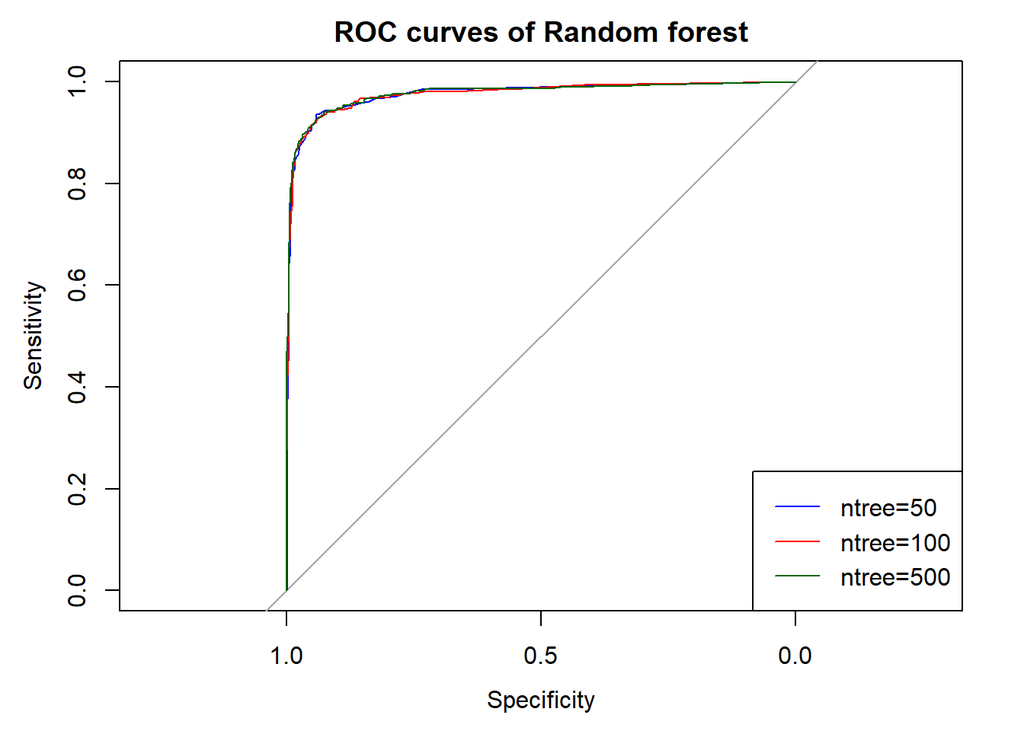

```r
legend("bottomright", legend = c(paste("ntree=50"),
                                 paste("ntree=100"),
                                 paste("ntree=500")),
       col = c("blue","red", "darkgreen"), lwd = 1)
```

**Note**

All AUCs are above 0.97, indicating excellent performance in discriminating emails. However, the improvements become marginal when the number of trees is increased. Therefore, in this case, adding more trees after 50 does add accuracy (possibly by reducing variance), but the computation time required in addition is large, compared to the improvement.

Furthermore, adding more trees after one point can risk overfitting because of the generalizing effects.

#### 💪 Problem 2.2

Predict the test data using the random forest classifier in Problem 2.1 with `ntree=100` following the rule: if $\mathrm{Pr}(y=1|\mathbf{x})>0.5 \Rightarrow y=1$, and compute the confusion matrix using the `confusionMatrix()` function from the `caret` package.

```r
set.seed(0)
random_forest <- randomForest(spam ~., data = train, ntree = 100)
y_predict_test_2.1 <- predict(random_forest, newdata = test, type = "prob")[,"spam"]
threshold <- 0.5
y_predict_test_2.2 <- as.factor(y_predict_test_2.1 > threshold) # as factor's default levels are FALSE and TRUE
levels(y_predict_test_2.2) <- c("not spam", "spam") # Renames the factor levels from default "FALSE"/"TRUE" to "not spam"/"spam" to ensure consistency with test$spam, which uses those labels.
confusionMatrix(data = y_predict_test_2.2, test$spam, positive = "spam")
```

```
Confusion Matrix and Statistics

          Reference
Prediction not spam spam
  not spam      661   38
  spam           36  415

               Accuracy : 0.9357
                 95% CI : (0.9199, 0.9491)
    No Information Rate : 0.6061
    P-Value [Acc > NIR] : <2e-16

                  Kappa : 0.8651

 Mcnemar's Test P-Value : 0.9075

            Sensitivity : 0.9161
            Specificity : 0.9484
         Pos Pred Value : 0.9202
         Neg Pred Value : 0.9456
             Prevalence : 0.3939
         Detection Rate : 0.3609
   Detection Prevalence : 0.3922
      Balanced Accuracy : 0.9322

       'Positive' Class : spam
```

We now turn our attention to boosting performed by the `xgboost()` function in the `xgboost` package. This function does not accept data frames as input (`X_train` above, among others, is of this type). Moreover, the function does not accept variables that are coded as factors. For logistic regression, it requires that the response is coded 0/1, where 1 is success. The following code transforms the features and response variable to this format.

```r
X_train_xgb <- as.matrix(X_train)
X_test_xgb <- as.matrix(X_test)
y_train_xgb <- as.integer(y_train) - 1
y_test_xgb <- as.integer(y_test) - 1
```

```r
suppressMessages(library(xgboost))
# Fit xgboost model
xgboost_model <- xgboost(data = X_train_xgb, label = y_train_xgb, nrounds = 100, objective = "binary:logistic",verbose = 0)
y_test_predict <- predict(xgboost_model, newdata = X_test_xgb) # predict probability
y_test_predict_xg <- as.factor(y_test_predict > threshold) # convert probability into 0/1

# Compute ROC and AUC
roc_xg <- roc(predictor = y_test_predict, response = y_test_xgb, levels= c(0, 1))
auc_xg <- auc(roc_xg)

# Compute confusion matrix
levels(y_test_predict_xg) <- c("not spam", "spam") # change the levels to not spam (0) and spam (1)
confusionMatrix(data = y_test_predict_xg, test$spam, positive = "spam")
```

```
Confusion Matrix and Statistics

          Reference
Prediction not spam spam
  not spam      658   34
  spam           39  419

               Accuracy : 0.9365
                 95% CI : (0.9208, 0.9499)
    No Information Rate : 0.6061
    P-Value [Acc > NIR] : <2e-16

                  Kappa : 0.8673

 Mcnemar's Test P-Value : 0.6397

            Sensitivity : 0.9249
            Specificity : 0.9440
         Pos Pred Value : 0.9148
         Neg Pred Value : 0.9509
             Prevalence : 0.3939
         Detection Rate : 0.3643
   Detection Prevalence : 0.3983
      Balanced Accuracy : 0.9345

       'Positive' Class : spam
```

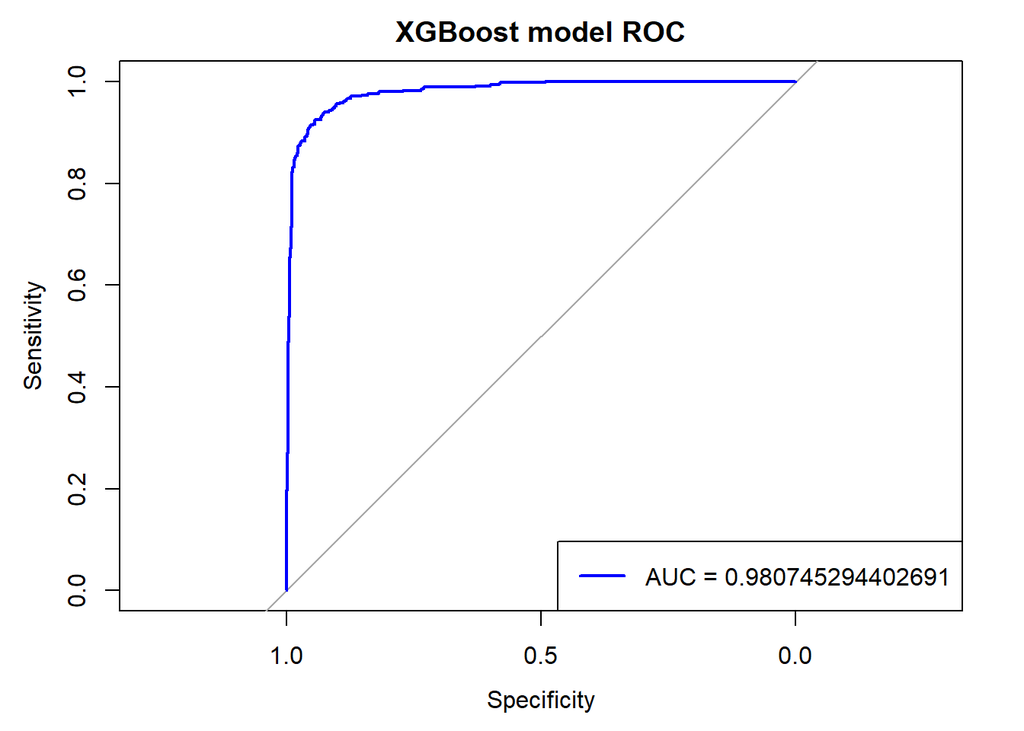

```r
# Plot ROC
plot(roc_xg, main = "XGBoost model ROC", col = "blue", lwd = 2)
legend("bottomright", legend = paste("AUC =", auc_xg), col = "blue", lwd = 2)
```

#### 💪 Problem 2.3

Use the `xgboost()` function in the `xgboost` package to fit three extreme gradient boosting regressions with the `nrounds` argument set to, respectively, 10, 25, and 50. In each case, plot the ROC curve and compute the area under the ROC curve (AUC) for the test data using the package `pROC()` (all plots in the same figure). Moreover, add the ROC plot for the random forest in Problem 2.1 with `ntree=100`. Comment on the results.

**Tip**

To get the `xgboost()` function to perform classification (instead of regression), supply the argument `objective="binary:logistic"`.

```r
nround <- c(10, 25, 50)

# Fit model
for (x in nround) {
  xgboost_model <- xgboost(data = X_train_xgb, label = y_train_xgb, nrounds = x, verbose = 0)
  y_test_predict <- predict(xgboost_model, newdata = X_test_xgb) # probability
  roc_xg <- roc(predictor = y_test_predict, response = y_test_xgb, levels= c(0,1))
  auc_xg <- auc(roc_xg)
  cat(glue("AUC {x} rounds: {auc_xg}\n\n"))
  if (x == 10){plot(roc_xg, lwd = 1, col = "blue", main = "ROC of XGBoost models")}
  else if (x == 25) {lines(roc_xg, lwd = 1, col = "red")}
  else {lines(roc_xg, lwd = 1, col = "darkgreen")}
}
```

```
AUC 10 rounds: 0.972909758314568
```

```
AUC 25 rounds: 0.974558261359785
```

```
AUC 50 rounds: 0.971566885516927
```

```r
# recreate the 100-tree random forest in 2.1
set.seed(0)
random_forest <- randomForest(spam ~., data = train, ntree = 100)
y_predict_test_2.1 <- predict(random_forest, newdata = test, type = "prob")[,"spam"]
roc_rf <- roc(response = y_test, predictor = y_predict_test_2.1, levels = c("not spam", "spam"))
auc_rf <- auc(roc_rf)
cat(glue("AUC 100-tree forest from 2.1: {auc_rf}\n\n")) # might be different from the AUC in 2.1 due to the "randomness" of random forest, even with the same seed
```

```
AUC 100-tree forest from 2.1: 0.976330283365163
```

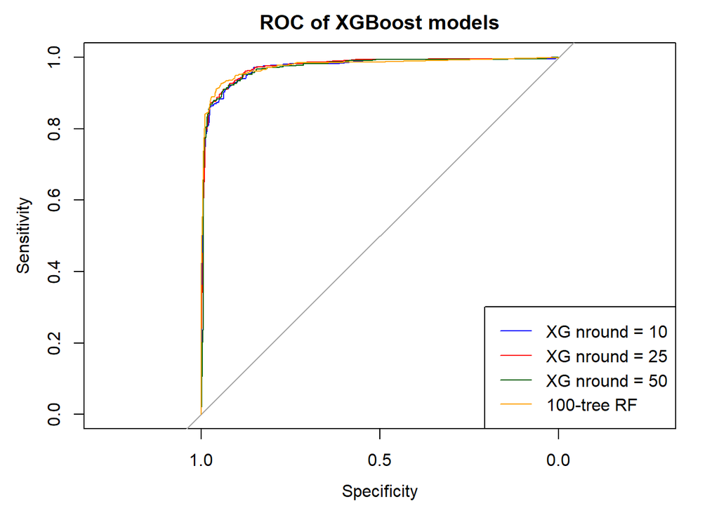

```r
# plot ROC from 2.1 random forest
lines(roc_rf, col = "orange", lwd = 1)

# add legends
legend("bottomright", legend = c(paste("XG nround = 10"),
                                 paste("XG nround = 25"),
                                 paste("XG nround = 50"),
                                 paste("100-tree RF")),
       col = c("blue","red", "darkgreen", "orange"), lwd = 1 )
```

**Note**

Overall, all models perform very well, with AUCs over 0.97, close to 1. Of which, the 100-tree RF model appears to be the best, both in AUC and in the graph. It is also noteworthy that AUC increases slightly when we add rounds from 10 to 25, but decreases at 50 rounds. This could be an indication that the initial increase in AUC reflects variance reduction, but too many trees can slightly increase variance again due to overfitting or noise capture, and therefore decreases estimating power.

#### 💪 Problem 2.4

Predict the test data using the extreme gradient boosting classifier in Problem 2.3 with `nrounds=25` following the rule: if $\mathrm{Pr}(y=1|\mathbf{x})>0.5 \Rightarrow y=1$, and compute the confusion matrix using the `confusionMatrix()` function from the `caret` package.

```r
# recreate the 25-round model from 2.3
xgboost_model_2.4 <- xgboost(data = X_train_xgb, label = y_train_xgb, nrounds = 25, verbose = 0)
y_test_predict <- predict(xgboost_model_2.4, newdata = X_test_xgb) # probability
y_predict_test_2.4 <- as.factor(y_test_predict > threshold) # convert to factor
levels(y_predict_test_2.4) <- c("not spam", "spam") # change levels
confusionMatrix(data = y_predict_test_2.4, test$spam, positive = "spam")
```

```
Confusion Matrix and Statistics

          Reference
Prediction not spam spam
  not spam      664   51
  spam           33  402

               Accuracy : 0.927
                 95% CI : (0.9104, 0.9413)
    No Information Rate : 0.6061
    P-Value [Acc > NIR] : < 2e-16

                  Kappa : 0.846

 Mcnemar's Test P-Value : 0.06362

            Sensitivity : 0.8874
            Specificity : 0.9527
         Pos Pred Value : 0.9241
         Neg Pred Value : 0.9287
             Prevalence : 0.3939
         Detection Rate : 0.3496
   Detection Prevalence : 0.3783
      Balanced Accuracy : 0.9200

       'Positive' Class : spam
```

## 3. Learning parametric models by gradient based optimisation

In this problem, we will learn how to implement gradient based optimisers (non-stochastic as well as stochastic) to learn the parameters of a parametric statistical model. When implementing a learning algorithm, it is advisable to use simulated data first to ensure that the algorithm works properly. With simulated data we know the answer, i.e. the true model parameters, and can thus check if our algorithm manages to learn (estimate) them correctly. Due to the randomness of the data generating process, however, we will not be able to obtain the exact values. We hope for estimates that are reasonably close[^2].

Our running example will be a Poisson regression model, where the response follows the Poisson distribution, i.e.

$$y|\beta, \mathbf{x} \sim \mathrm{Poisson}(\exp\left(\mathbf{x}^\top \mathbf{\beta}\right)). \tag{1}$$

To keep notation simple, we sometimes skip conditioning on $\mathbf{x}$ since we assume they are known (we only model $y$). To proceed simulating, say $n=1000$, $y$ observations, we need given values of $x$ first. The following function generates $n=1000$ such observations uniformly on the unit interval[^3]. It uses the `set.seed()` function to ensure the same features are generated every time.

```r
#rm(list=ls()) # Remove variables
#cat("\014") # Clean workspace
gen_x <- function(seed=123){
  set.seed(seed)
  return(runif(min = 0, max = 1, n = 1000))
}
# Test
x <- gen_x()
class(x)
```

```
[1] "numeric"
```

```r
length(x)
```

```
[1] 1000
```

```r
head(x)
```

```
[1] 0.2875775 0.7883051 0.4089769 0.8830174 0.9404673 0.0455565
```

#### 💪 Problem 3.1

Simulate $n=1000$ independent (conditionally on $x$) $y$ observations from the Poisson regression model
$$y|\beta_0,\beta_1 \sim \mathrm{Poisson}(\exp\left(\beta_0 + \beta_1x \right)),$$
with the true parameters $\beta_0= 0.3$ and $\beta_1= 2.5$.

**Tip**

The `rpois()` function can be used to simulate random numbers from the Poisson distribution. The argument `lambda` is used to specify the expected value of the distribution.

```r
lambda <- exp(0.3 +2.5*x)
set.seed(123)
y <- rpois(1000, lambda = lambda) #draw 1000 random y
length(y) # self-check
```

```
[1] 1000
```

```r
head(y)
```

```
[1]  2 12  3 16  7  1
```

#### 💪 Problem 3.2

In the same figure, plot the scatter $\{x_i, y_i\}_{i=1}^n$ and the conditional expected value $\mathbb{E}(y|x)$ as a function of $x$ given the true parameter values.

**Tip**

When plotting the conditional expected value as a function of $x$, create a variable `x_grid<-seq(0, 1, length.out=10000)` and evaluate the expected value on the grid.

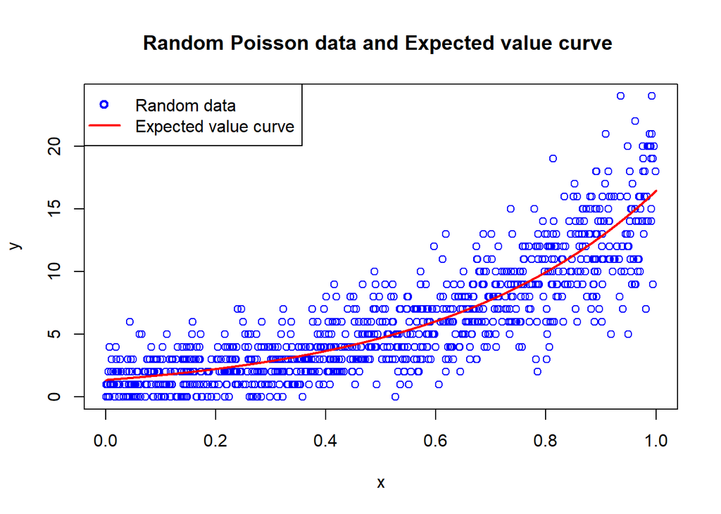

```r
#  Plot the scatter for random x and y just created
plot(x = x, y = y, col = "blue", main = "Random Poisson data and Expected value curve ")

# Plot the conditional expected value
x_grid<-seq(0, 1, length.out=10000)
y_grid <- exp(0.3 +2.5*x_grid) # expected value of y = lambda
lines(x = x_grid, y = y_grid, col = "red", lwd = 2)

legend("topleft", legend = c("Random data", "Expected value curve"), col = c("blue", "red"), pch = c(1, NA), lty = c(NA, 1),
       lwd = 2)
```

We now turn our attention to learning (estimating) the parameters $\beta_0$ and $\beta_1$ from the dataset. The cross-entropy between the empirical distribution of the data and the parametric model is minimised when the log-likelihood is used as a loss function (cost function) for learning the parameters. The log-likelihood is defined as the log of the density (to be exact, the probability mass function here since $y$ is discrete) of the sample **viewed as a function of the parameters (with the sample fixed)**, which for our model is
$$\ell(\beta_0, \beta_1)=\log p(y_1,y_2,\dots,y_n|x_1,x_2,\dots,x_n,\beta_0, \beta_1).$$

Cross-entropy is minimized when the log-likelihood is maximized. In other words, to estimate the best parameters $\beta_0$ and $\beta_1$, we need to find the $\beta_0$ and $\beta_1$ values that maximize $l(\beta_0, \beta_1)$ .

#### 💪 Problem 3.3

Derive (analytically) theb log-likelihood $\ell(\beta_0, \beta_1)$ for the Poisson regression model.

**Tip**

The probability mass function of the Poisson model with expected value $\mu>0$ is given by
$$p(y|\mu)=\frac{\mu^y\exp(-\mu)}{y!}.$$
Now use that the $y$s are independent (conditionally on the $x$s) and think about how $\mu$ relates to $\beta_0, \beta_1$ in our model. Finally, do not forget the logarithm!

**Note**

The likelihood function is:

$L(\beta_0, \beta_1) = \prod_{i=1}^{n}\frac{\mu_{i}^{y_i} \times \exp(-\mu_i)}{y_{i}!}$

With $\mu_i = exp\left(\beta_0 + \beta_1 \times x_i\right)$, we have:

$L(\beta_0, \beta_1) =\prod_{i=1}^{n} \frac{[exp(\beta_0 + \beta_1\times x_i)]^{y_i} \times exp(-exp(\beta_0 + \beta_1 \times x_i)}{y_i!}$

So the log-likelihood function is:

$\log[L(\beta_0, \beta_1)] = \ell(\beta_0, \beta_1) = \log\left(\prod_{i=1}^{n} \frac{[exp(\beta_0 + \beta_1\times x_i)]^{y_i} \times exp(-exp(\beta_0 + \beta_1 \times x_i)}{y_i!} \right)$

$=\sum_{i=1}^{n} {\log{[exp(\beta_0 + \beta_1 \times x_i)]^{y_i}} + \log{exp[-\exp(\beta_0 + \beta_1 \times x_i)]} - \log(y_i!)}$

$= \sum_{i=1}^{n} {y_i \times \log{[exp(\beta_0 + \beta_1 \times x_i)]} - exp(\beta_0 + \beta_1 \times x_i) - \log(y_i!)}$

$= \sum_{i=1}^{n} {y_i \times (\beta_0 + \beta_1 \times x_i) - exp(\beta_0 + \beta_1 \times x_i) - \log(y_i!) }$

Define the cost function $J(\beta_0, \beta_1) = -\frac{1}{n}\ell(\beta_0, \beta_1)$, i.e. as the average negative log-density of the observations (viewed as a function of the parameters to learn). The motivation of the form of the cost function is the following. First, note that the larger the log-likelihood for a set of parameter values is, the more plausible that those parameter values generated the given dataset. Thus, to turn the log-likelihood to a cost – a quantity where less (and not more) is better – it is multiplied by a negative sign. The average part of the cost function (division by $n$) is so that it is comparable over datasets of different sizes.

The cost function $J(\beta_0, \beta_1)$ is the objective function we minimise to learn the parameters, i.e. our estimates $\widehat{\beta}=(\widehat{\beta}_0,\widehat{\beta}_1)$ are obtained as
$$\widehat{\beta}=\arg \min_{\beta_0, \beta_1} J(\beta_0, \beta_1).$$

Your task is to implement a gradient descent algorithm to minimise $J(\beta_0, \beta_1)$ for the Poisson regression model. This requires two functions, one that evaluates $J(\beta_0, \beta_1) = -\frac{1}{n}\ell(\beta_0, \beta_1)$, and another that evaluates its gradient, i.e. $\nabla J(\beta_0, \beta_1) = -\frac{1}{n}\nabla\ell(\beta_0, \beta_1)$.

**Note**

We have the loss function: $\ell(\beta_0, \beta_1) = \sum_{i=1}^{n} {y_i \times (\beta_0 + \beta_1 \times x_i) - exp(\beta_0 + \beta_1 \times x_i) - \log(y_i!) }$

So the cost function $J(\beta_0, \beta_1) = -\frac{1}{n}\ell(\beta_0, \beta_1)$ can be expanded as:

$J(\beta_0, \beta_1) = -\frac{1}{n}\ell(\beta_0, \beta_1) = -\frac {1}{n} \sum_{i=1}^{n} {y_i \times (\beta_0 + \beta_1 \times x_i) - exp(\beta_0 + \beta_1 \times x_i) - \log(y_i!)}$

To find the gradient descent $\beta_0$, we calculate the derivative of $J(\beta_0, \beta_1)$ with respect to $\beta_0$: $J(\beta_0, \beta_1)' = -\frac{1}{n}y_i - exp(\beta_0 + \beta_1 \times x_i)$

Similarly for $\beta_1$: $J(\beta_0, \beta_1)' = -\frac{1}{n} x_i \times \left(y_i - exp(\beta_0 + \beta_1 \times x_i)\right)$

Next, we can implement in R to try random values for $\beta_0$ and $\beta_1$, calculate the step size and new $\beta$s.

```r
# we aim to maximize likelihood
# Loss function (log-likelihood)
loss_function <- function(x, y, beta){
  lambda <- exp(beta[1] + beta[2]*x)
  log_y_factorial <- log(factorial(y))
  return(sum(y*(beta[1] + beta[2]*x) - lambda - log_y_factorial))
}

# Cost function: negative average log-likelihood
cost_function <- function(x, y, beta){
  n <- length(y)
  return(-1/n * loss_function(x, y, beta))
}

# Gradient of cost function
beta_cost_gradient <- function(x, y, beta){
  n <- length(y)
  lambda <- exp(beta[1] + beta[2]*x)
  beta0_derivative <- -1/n * sum(y - lambda) # derivative of cost function with respect to beta0
  beta1_derivative <- -1/n * sum((y - lambda) * x) # derivative of cost function with respect to beta1
  return(c(beta0_derivative, beta1_derivative))
}

# Gradient descent of cost function optimization
cost_gradient_descent <- function(x, y, steps, learning_rate){
  beta <- c(0, 0)  # Initial guess
  beta_matrix <- matrix(0, nrow = steps, ncol = 2) # prepare for the plot in 3.6
  cost_vector <- numeric(steps)
  grad_norm_vector <- numeric(steps) #prepare for the plot in 3.6


  for (i in 1:steps){
    grad <- beta_cost_gradient(x, y, beta)
    beta <- beta - learning_rate * grad
    cost_vector[i] <- cost_function(x, y, beta)

    beta_matrix[i, ] <- beta # prepare for the plot in 3.6
    grad_norm_vector[i] <- norm(as.matrix(grad), type = "2") # prepare for the tét in 3.6
  }
  return(list(beta = beta, cost = cost_vector, grad_norm = grad_norm_vector, beta_matrix = beta_matrix))
}
```

```r
# Trial run with steps = 1000 and learning rate = 0.05
# Run gradient descent
result <- cost_gradient_descent(x, y, steps = 1000, learning_rate = 0.05)

# Output estimated beta
result$beta
```

```
[1] 0.2556194 2.5251714
```

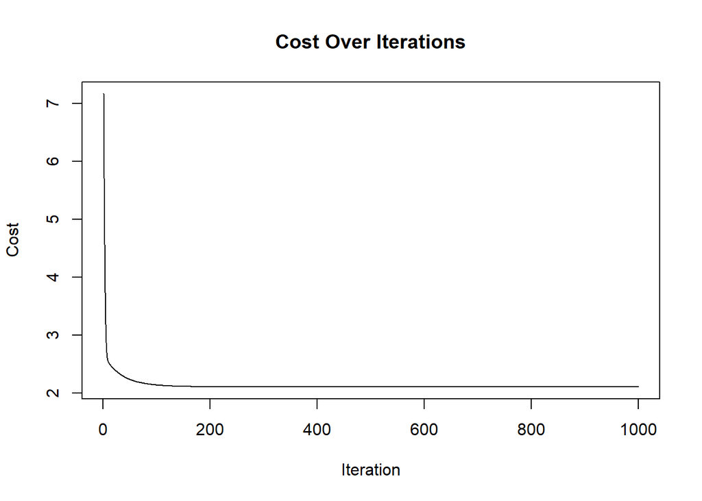

```r
# plot the cost to check how it converge
plot(result$cost, type = "l", main = "Cost Over Iterations", xlab = "Iteration", ylab = "Cost")
```

#### 💪 Problem 3.4

Derive (analytically) the gradient of the log-likelihood $\ell(\beta_0, \beta_1)$ for the Poisson regression model.

**Tip**

Because of the (conditional) independence assumption
$$\nabla \ell(\beta_0, \beta_1)=\sum_{i=1}^n \nabla \log p(y_i|x_i,\beta_0, \beta_1),$$
and note that
$$\nabla \log p(y_i|x_i,\beta_0, \beta_1)=\left(\frac{\partial}{\partial\beta_0}\log p(y_i|x_i,\beta_0, \beta_1), \frac{\partial}{\partial\beta_1}\log p(y_i|x_i,\beta_0, \beta_1) \right)^\top.$$

**Note**

We have the loss function: $\ell(\beta_0, \beta_1) = \sum_{i=1}^{n} {y_i \times (\beta_0 + \beta_1 \times x_i) - exp(\beta_0 + \beta_1 \times x_i) - \log(y_i!) }$

To find the gradient of $\ell(\beta_0, \beta_1)$, we compute the derivative of it with respect to $\beta_0$ and $\beta_1$ separately:  
$\ell_{\beta_0}(\beta_0, \beta_1)' = \sum_{i=1}^{n}y_i - exp(\beta_0 + \beta_1 \times x_i)$

$\ell_{\beta_1}(\beta_0, \beta_1)' = \sum_{i=1}^{n} x_i \times (y_i - exp(\beta_0 +\beta_1 \times x_i))$

So we have:

$\nabla \ell(\beta_0, \beta1) = \sum_{i=1}^{n}\begin{pmatrix} y_i - \exp(\beta_0 + \beta_1 x_i) \\x_i \left( y_i - \exp(\beta_0 + \beta_1 x_i) \right)\end{pmatrix}$

#### 💪 Problem 3.5

Code two functions, one that evaluates $\ell(\beta_0, \beta_1)$, and another that evaluates its gradient, i.e. $\nabla\ell(\beta_0, \beta_1)$. Note that the first function is scalar valued, whereas the second is vector valued ($2\times 1$ in our case).

```r
# I already coded the loss function above, in 3.3.
# code a function the evaluate the loss's gradient
beta_loss_gradient <- function(x, y, beta){
  lambda = exp(beta[1] + beta[2]*x)
  beta0_derivative <- sum(y - lambda) # derivative of the loss function with respect to beta0
  beta1_derivative <- sum(x*(y - lambda)) # derivative of the loss function with respect to beta1
  return(c(beta0_derivative, beta1_derivative))
}
```

#### 💪 Problem 3.6

Implement gradient descent (Algorithm 5.1 in Lindholm et al. (2022)[^4]) to learn the parameters in the Poisson regression model by minimising the cost function $J(\beta_0, \beta_1)$. Implement three different algorithms, with step sizes $\gamma=0.01, 0.1, 0.25$, and using $(0,0)$ as starting value. Note that Algorithm 5.1 has a stopping condition which states that it stops when the change in the parameter updates from one iteration to the other is small enough. If a wrong implementation is given, or the step size is chosen such that the algorithm does not converge, the code might get stuck in an infinite while loop (the condition to exit the loop is never met). For this reason, we here perform 200 iterations of the algorithm only (regardless of convergence or not). Comment on the results.

**Tip**

Code two functions, one that evaluates $J(\beta_0, \beta_1) = -\frac{1}{n}\ell(\beta_0, \beta_1)$ (scalar valued function), and another that evaluates its gradient, i.e. $\nabla J(\beta_0, \beta_1) = -\frac{1}{n}\nabla\ell(\beta_0, \beta_1)$ (vector valued function). Call these two functions when implementing the gradient descent algorithm.

To inspect the effects of different learning rates one may plot (for example):

- $J(\beta_0^{(t)}, \beta_1^{(t)})$, where $t$ is the iteration number and $\beta_0^{(t)}, \beta_1^{(t)}$ are the corresponding updates at that iteration. Plotting this quantity vs the iteration number illustrates the convergence as it should settle when reaching the minimum. The faster it settles, the faster the convergence.
- $||\nabla J(\beta_0^{(t)}, \beta_1^{(t)})||_2$ , i.e. the Euclidean norm of the gradient, at each iterate as a function of the iteration number. This should eventually go to zero (the gradient is zero at the optimal value). The Euclidean norm of a vector `v` can be computed by `norm(v, type="2")`.
- $\beta_0^{(t)}, \beta_1^{(t)}$, i.e. the updates vs the iteration number. These should converge to (the vicinity of) the true values.

```r
# We already defined cost evaluation, cost gradient and cost gradient descent functions in 3.3
```

```r
# Run gradient descent with 3 learning rates/step sizes
result_001 <- cost_gradient_descent(x, y, learning_rate = 0.01, steps = 200 )
cat("Step size 0.01 beta: ",result_001$beta, "\n")
```

```
Step size 0.01 beta:  0.902375 1.584522
```

```r
result_01  <- cost_gradient_descent(x, y, learning_rate = 0.1, steps = 200)
cat("Step size 0.1 beta: ",result_01$beta, "\n")
```

```
Step size 0.1 beta:  0.2624808 2.515604
```

```r
result_025 <- cost_gradient_descent(x, y, learning_rate = 0.25, steps = 200)
cat("Step size 0.25 beta: ",result_025$beta, "\n")
```

```
Step size 0.25 beta:  0.5434126 2.659081
```

**Note**

With step size of 0.1, we got closer to true beta, but went a little overboard. If we stop earlier, at 180-190 iterations, we may get a better results.

With an even larger step size of 0.25, the estimates are too far off. especially in the beta path graph, it looks highly unstable, overshoots and diverges before the first 10th iteration.

To improve this estimate, we can either tune the step size between 0.01 and 0.1, or increase the number of iterations for small step size/decrease for large step size.

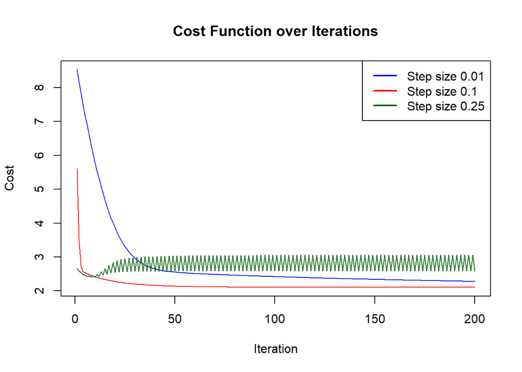

```r
#$J(\beta_0^{(t)}, \beta_1^{(t)})$, where $t$ is the iteration number and $\beta_0^{(t)}, \beta_1^{(t)}$ are the corresponding updates at that iteration. Plotting this quantity vs the iteration number illustrates the convergence as it should settle when reaching the minimum. The faster it settles, the faster the convergence.
plot(result_001$cost, type = "l", col = "blue", ylim = range(c(result_001$cost, result_01$cost, result_025$cost)),
     xlab = "Iteration", ylab = "Cost", main = "Cost Function over Iterations")
lines(result_01$cost, col = "red")
lines(result_025$cost, col = "darkgreen")
legend("topright", legend = c("Step size 0.01", "Step size 0.1", "Step size 0.25"), col = c("blue", "red", "darkgreen"), lwd = 2)
```

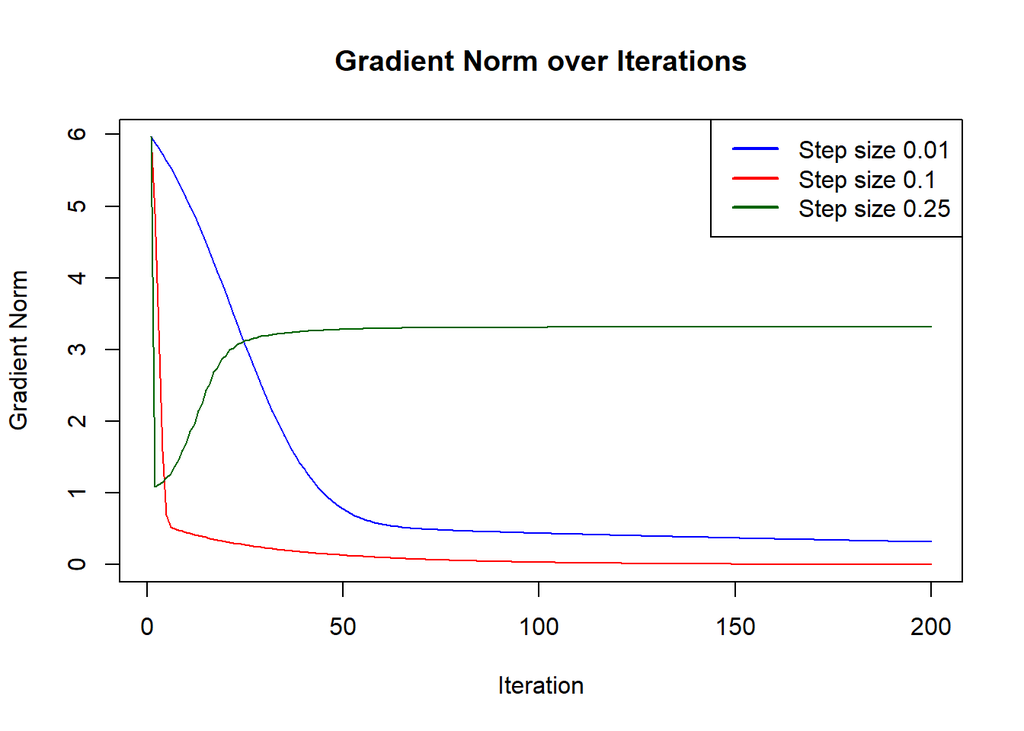

```r
#the Euclidean norm of the gradient, at each iterate as a function of the iteration number. This should eventually go to zero (the gradient is zero at the optimal value). The Euclidean norm of a vector v can be computed by norm(v, type="2").
plot(result_001$grad_norm, type = "l", col = "blue", ylim = range(c(result_001$grad_norm, result_01$grad_norm, result_025$grad_norm)),
     xlab = "Iteration", ylab = "Gradient Norm", main = "Gradient Norm over Iterations")
lines(result_01$grad_norm, col = "red")
lines(result_025$grad_norm, col = "darkgreen")
legend("topright", legend = c("Step size 0.01", "Step size 0.1", "Step size 0.25"), col = c("blue", "red", "darkgreen"), lwd = 2)
```

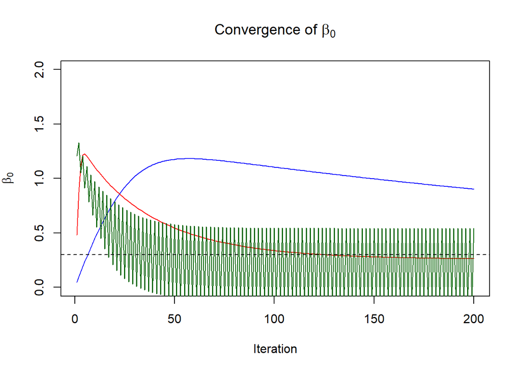

```r
# the updates vs the iteration number. These should converge to (the vicinity of) the true values.
true_beta <- c(0.3, 2.5)

plot(result_001$beta_matrix[,1], type = "l", col = "blue", ylim = c(0, 2), ylab = expression(beta[0]), xlab = "Iteration", main = expression(paste("Convergence of ", beta[0])))
lines(result_01$beta_matrix[,1], col = "red")
lines(result_025$beta_matrix[,1], col = "darkgreen")
abline(h = true_beta[1], col = "black", lty = 2)
```

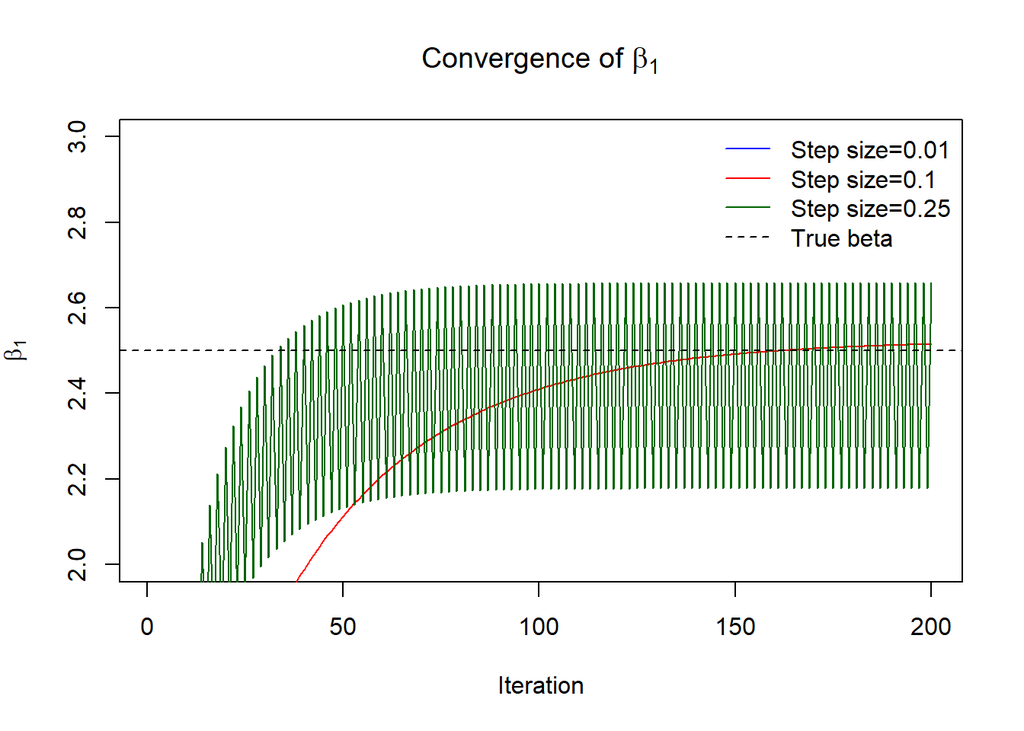

```r
plot(result_001$beta_matrix[,2], type = "l", col = "blue", ylim = c(2, 3), ylab = expression(beta[1]), xlab = "Iteration", main = expression(paste("Convergence of ", beta[1])))
lines(result_01$beta_matrix[,2], col = "red")
lines(result_025$beta_matrix[,2], col = "darkgreen")
abline(h = true_beta[2], col = "black", lty = 2)
legend("topright", legend = c("Step size=0.01", "Step size=0.1", "Step size=0.25", "True beta"),
       col = c("blue", "red", "darkgreen", "black"), lty = c(1, 1, 1, 2), bty = "n")
```

#### 💪 Problem 3.7

Run stochastic gradient descent (Algorithm 5.3 in Lindholm et al. (2022)) for $E=20$ epochs to learn the parameters in the Poisson regression model. Experiment with three different mini-batch sizes, $n_b=10,50,100$ and use the diminishing learning rate $\gamma^{(t)}=0.5/t^{0.6}$. Which mini-batch size seems to converge the fastest?

**Tip**

Some of the suggested figures in Problem 3.6 may be useful for illustrating the effects of different mini-batch sizes.

```r
set.seed(123)
stochastic_gradient_descent <- function(x, y, batch_size, epochs) {
  n <- length(y)
  beta <- c(0, 0) # initial guess
  t <- 1  # iteration counter, used in diminishing learning rate

  # For storing results
  number_of_steps <- ceiling(n / batch_size) * epochs # round up number of steps
  cost_vector <- numeric(number_of_steps)
  grad_norm_vector <- numeric(number_of_steps)
  beta_matrix <- matrix(0, nrow = number_of_steps, ncol = 2)

  for (e in 1:epochs) {
    # Shuffle data
    index <- sample(1:n) # shuffle 1:1
    x_shuffled <- x[index] # rearrange x vector using the shuffled order
    y_shuffled <- y[index] # rearrange y vector using the shuffled order

    # Mini-batches
    for (i in seq(1, n, by = batch_size)) { # slice the data set into batches
      # Batch indices
      batch_index <- i:(i + batch_size - 1) # extract the indices of current batch, going from i_th element to (i + batch_size - 1)_th element.
      x_batch <- x_shuffled[batch_index]
      y_batch <- y_shuffled[batch_index]

      # Diminishing learning rate
      gamma_t <- 0.5 / t^0.6

      # Gradient and update
      grad <- beta_cost_gradient(x_batch, y_batch, beta)
      beta <- beta - gamma_t * grad

      # Store results
      cost_vector[t] <- cost_function(x, y, beta)  # use full data for cost
      grad_norm_vector[t] <- norm(as.matrix(grad), type = "2")
      beta_matrix[t, ] <- beta

      t <- t + 1  # increment step counter
    }
  }

  return(list(
    beta = beta,
    cost_vector = cost_vector,
    grad_norm_vector = grad_norm_vector,
    beta_matrix = beta_matrix
  ))
}
```

```r
set.seed(123)

stochastic_gradient_descent <- function(x, y, batch_size, epochs) {
  n <- length(y)
  beta <- c(0, 0) # initial guess
  t <- 1  # iteration counter

  # Storage
  number_of_steps <- ceiling(n / batch_size) * epochs
  cost_vector <- numeric(number_of_steps)
  grad_norm_vector <- numeric(number_of_steps)
  beta_matrix <- matrix(0, nrow = number_of_steps, ncol = 2)

  for (e in 1:epochs) {
    # Shuffle data each epoch
    index <- sample(1:n)
    x_shuffled <- x[index]
    y_shuffled <- y[index]

    # Mini-batch iteration
    for (i in seq(1, n, by = batch_size)) {
      batch_index <- i:(i + batch_size - 1)
      batch_index <- batch_index[batch_index <= n]  # avoid going out of bounds
      x_batch <- x_shuffled[batch_index]
      y_batch <- y_shuffled[batch_index]

      # Diminishing learning rate
      gamma_t <- 0.5 / t^0.6

      # Gradient and update
      grad <- beta_cost_gradient(x_batch, y_batch, beta)
      beta <- beta - gamma_t * grad

      # Store results
      cost_vector[t] <- cost_function(x, y, beta)
      grad_norm_vector[t] <- norm(as.matrix(grad), type = "2")
      beta_matrix[t, ] <- beta
      t <- t + 1
    }
  }

  # Compute mean cost per epoch (for smoother plotting)
  steps_per_epoch <- ceiling(n / batch_size)
  epoch_cost <- sapply(1:epochs, function(e) {
    start_idx <- (e - 1) * steps_per_epoch + 1
    end_idx <- min(e * steps_per_epoch, length(cost_vector))
    mean(cost_vector[start_idx:end_idx])
  })

  return(list(
    beta = beta,
    cost_vector = cost_vector,
    grad_norm_vector = grad_norm_vector,
    beta_matrix = beta_matrix,
    epoch_cost = epoch_cost
  ))
}

# --- Run SGD with different batch sizes ---
result_b10 <- stochastic_gradient_descent(x, y, batch_size = 10, epochs = 20)
result_b50 <- stochastic_gradient_descent(x, y, batch_size = 50, epochs = 20)
result_b100 <- stochastic_gradient_descent(x, y, batch_size = 100, epochs = 20)

# to decide which batch size is the fastest to converge, I set a threshold, and check which batch size take smallest number of steps to reach that threshold.
threshold <- 0.1
steps_b10 <- which(result_b10$grad_norm_vector < threshold)[1]
steps_b50 <- which(result_b50$grad_norm_vector < threshold)[1]
steps_b100 <- which(result_b100$grad_norm_vector < threshold)[1]

cat("Steps to converge:\n",
    "Batch 10:", steps_b10, "\n",
    "Batch 50:", steps_b50, "\n",
    "Batch 100:", steps_b100, "\n")
```

```
Steps to converge:
 Batch 10: 20
 Batch 50: 33
 Batch 100: 52
```

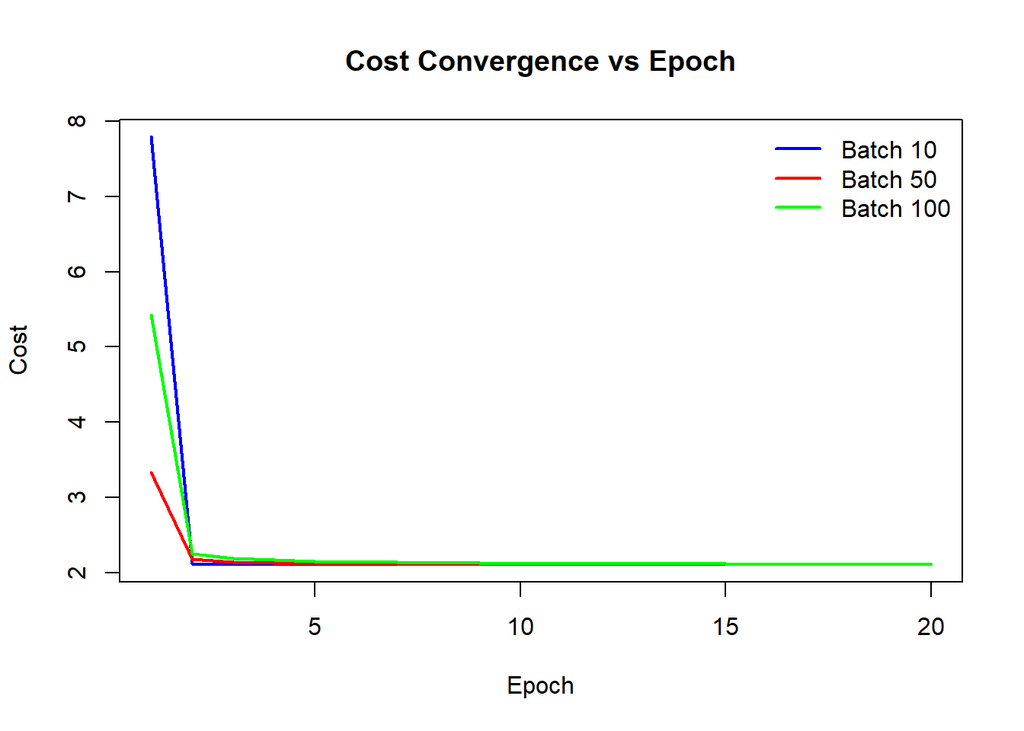

```r
# --- Plot cost convergence ---
plot(result_b10$epoch_cost, type = "l", col = "blue", lwd = 2, ylim = range(
  c(result_b10$epoch_cost, result_b50$epoch_cost, result_b100$epoch_cost)
), xlab = "Epoch", ylab = "Cost", main = "Cost Convergence vs Epoch")

lines(result_b50$epoch_cost, col = "red", lwd = 2)
lines(result_b100$epoch_cost, col = "green", lwd = 2)
legend("topright", legend = c("Batch 10", "Batch 50", "Batch 100"),
       col = c("blue", "red", "green"), lwd = 2, bty = "n")
```

```r
result_b10 <- stochastic_gradient_descent(x, y, batch_size = 10, epochs = 20)
cat("Beta batch 10:", result_b10$beta, "\n\n")
```

```
Beta batch 10: 0.2680526 2.520374
```

```r
result_b50 <- stochastic_gradient_descent(x, y, batch_size = 50, epochs = 20)
cat("Beta batch 50:", result_b50$beta, "\n\n")
```

```
Beta batch 50: 0.3173809 2.421579
```

```r
result_b100 <- stochastic_gradient_descent(x, y, batch_size = 100, epochs = 20)
cat("Beta batch 100:", result_b100$beta, "\n")
```

```
Beta batch 100: 0.3635343 2.37154
```

**Note**

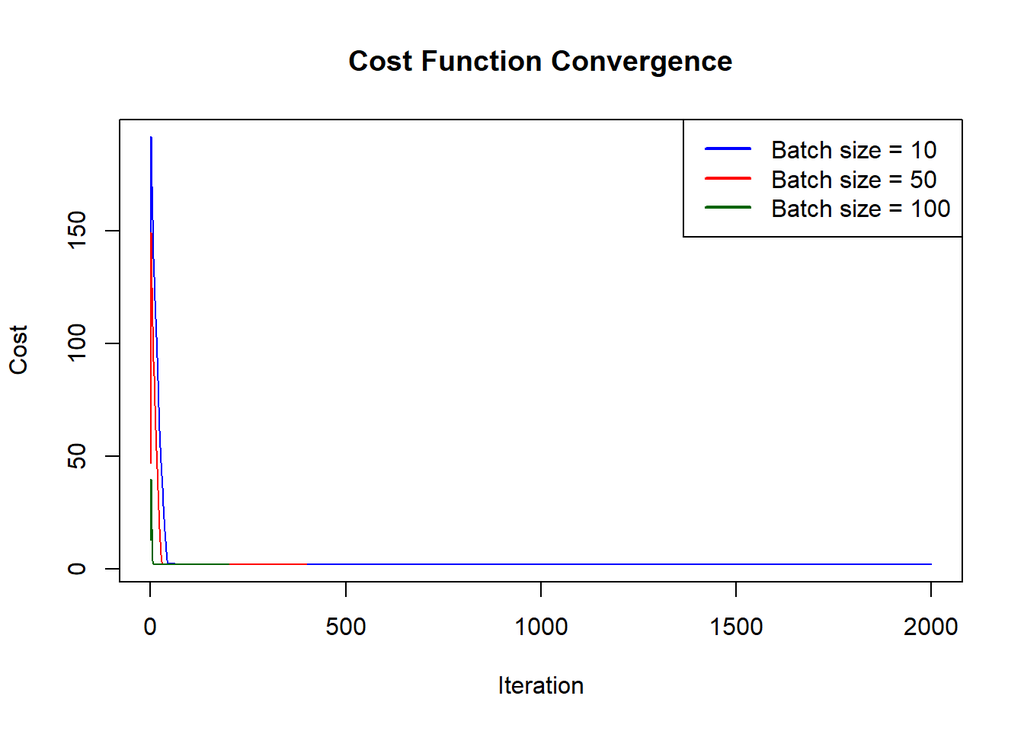

```r
plot(result_b10$cost_vector, type = "l", col = "blue", ylim = range(c(result_b10$cost_vector, result_b50$cost_vector, result_b100$cost_vector), na.rm = TRUE),
     xlab = "Iteration", ylab = "Cost", main = "Cost Function Convergence")
lines(result_b50$cost_vector, col = "red")
lines(result_b100$cost_vector, col = "darkgreen")
legend("topright", legend = c("Batch size = 10", "Batch size = 50", "Batch size = 100"), col = c("blue", "red", "darkgreen"), lwd = 2)
```

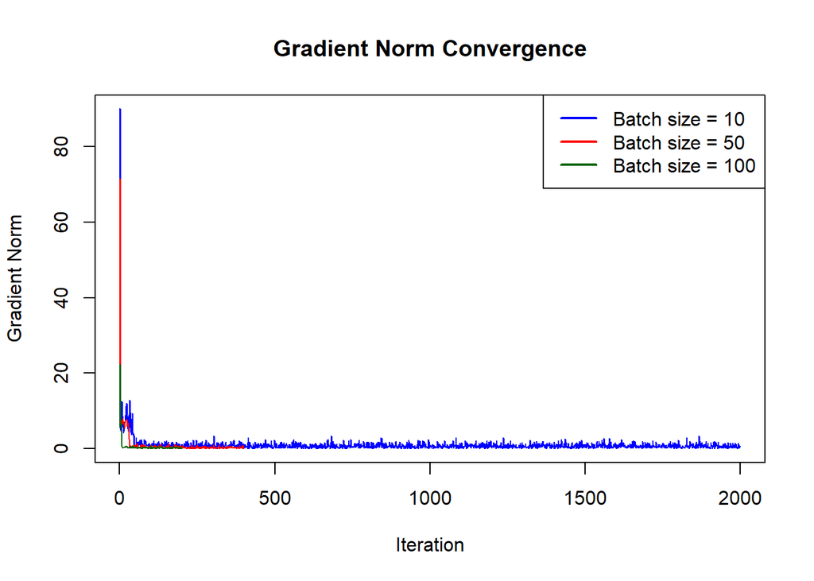

```r
plot(result_b10$grad_norm_vector, type = "l", col = "blue", ylim = range(c(result_b10$grad_norm_vector, result_b50$grad_norm_vector, result_b100$grad_norm_vector), na.rm = TRUE),
     xlab = "Iteration", ylab = "Gradient Norm", main = "Gradient Norm Convergence")
lines(result_b50$grad_norm_vector, col = "red")
lines(result_b100$grad_norm_vector, col = "darkgreen")
legend("topright", legend = c("Batch size = 10", "Batch size = 50", "Batch size = 100"), col = c("blue", "red", "darkgreen"), lwd = 2)
```

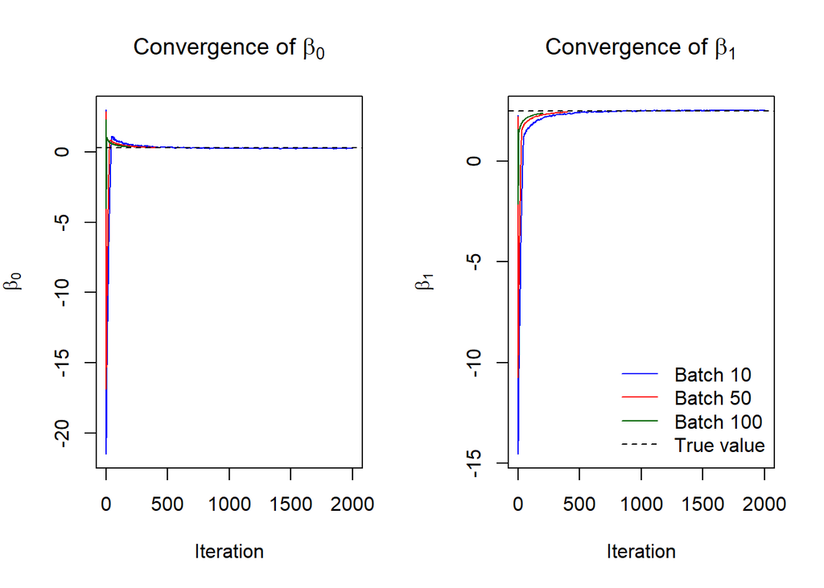

```r
par(mfrow = c(1, 2))

# Beta 0
plot(result_b10$beta_matrix[, 1], type = "l", col = "blue", ylab = expression(beta[0]), xlab = "Iteration",
     main = expression(paste("Convergence of ", beta[0])))
lines(result_b50$beta_matrix[, 1], col = "red")
lines(result_b100$beta_matrix[, 1], col = "darkgreen")
abline(h = true_beta[1], col = "black", lty = 2)

# Beta 1
plot(result_b10$beta_matrix[, 2], type = "l", col = "blue", ylab = expression(beta[1]), xlab = "Iteration",
     main = expression(paste("Convergence of ", beta[1])))
lines(result_b50$beta_matrix[, 2], col = "red")
lines(result_b100$beta_matrix[, 2], col = "darkgreen")
abline(h = true_beta[2], col = "black", lty = 2)

legend("bottomright", legend = c("Batch 10", "Batch 50", "Batch 100", "True value"),
       col = c("blue", "red", "darkgreen", "black"), lty = c(1, 1, 1, 2), bty = "n")
```

## 4. Learning parametric models by second order optimisation

We now improve the optimisation by resorting to second order methods. One such method is Newton’s method, which can be seen as adjusting the gradient to account for the local curvature in each step. The curvature is measured by the so-called Hessian of the cost function, which is the matrix of second order (partial) derivatives.

#### 💪 Problem 4.1

Derive (analytically) the Hessian of the log-likelihood $\ell(\beta_0, \beta_1)$ for the Poisson regression model.

**Tip**

Because of the (conditional) independence assumption
$$\nabla\nabla^\top \ell(\beta_0, \beta_1)=\sum_{i=1}^n \nabla\nabla^\top \log p(y_i|x_i,\beta_0, \beta_1),$$
and note that

$$\nabla\nabla^\top \log p(y_i|x_i,\beta_0, \beta_1) = \begin{bmatrix}
\frac{\partial^2}{\partial\beta_0^2}\log p(y_i|x_i,\beta_0, \beta_1) & \frac{\partial^2}{\partial\beta_0\partial\beta_1}\log p(y_i|x_i,\beta_0, \beta_1) \\
\frac{\partial^2}{\partial\beta_1\partial\beta_0}\log p(y_i|x_i,\beta_0, \beta_1) & \frac{\partial^2}{\partial\beta_1^2}\log p(y_i|x_i,\beta_0, \beta_1)
\end{bmatrix}.$$

**Note**

From the Poisson regression in problem 3, we have:

The likelihood function is:

$L(\beta_0, \beta_1) = \prod_{i=1}^{n}\frac{\mu_{i}^{y_i} \times \exp(-\mu_i)}{y_{i}!}$

With $\mu_i = exp\left(\beta_0 + \beta_1 \times x_i\right)$, we have:

$L(\beta_0, \beta_1) =\prod_{i=1}^{n} \frac{[exp(\beta_0 + \beta_1\times x_i)]^{y_i} \times exp(-exp(\beta_0 + \beta_1 \times x_i)}{y_i!}$

So the log-likelihood function is:

$\log[L(\beta_0, \beta_1)] = \ell(\beta_0, \beta_1) = \log\left(\prod_{i=1}^{n} \frac{[exp(\beta_0 + \beta_1\times x_i)]^{y_i} \times exp(-exp(\beta_0 + \beta_1 \times x_i)}{y_i!} \right)$

$=\sum_{i=1}^{n} {\log{[exp(\beta_0 + \beta_1 \times x_i)]^{y_i}} + \log{exp[-\exp(\beta_0 + \beta_1 \times x_i)]} - \log(y_i!)}$

$= \sum_{i=1}^{n} {y_i \times \log{[exp(\beta_0 + \beta_1 \times x_i)]} - exp(\beta_0 + \beta_1 \times x_i) - \log(y_i!)}$

$= \sum_{i=1}^{n} {y_i \times (\beta_0 + \beta_1 \times x_i) - exp(\beta_0 + \beta_1 \times x_i) - \log(y_i!) }$

The gradient of the log-likelihood function is:

With respect to $\beta_0$: $\ell_{\beta_0}(\beta_0, \beta_1)' = \sum_{i=1}^{n} {y_i - exp(\beta_0 +\beta_1 \times x_i)}$

With respect to $\beta_1$: $\ell_{\beta_1}(\beta_0, \beta_1)' = \sum_{i=1}^{n} {x_i \times y_i - exp(\beta_0 + \beta_1 \times x_i) \times x_i}$

The Hessian of the log-likelihood function is:

With respect to $\beta_0$: $\ell_{\beta_0}(\beta_0, \beta_1)'' = \frac{\partial^2}{\partial\beta_0^2}\log p(y_i|x_i,\beta_0, \beta_1) = \sum_{i=1}^{n} -exp(\beta_0 + \beta_1 \times x_i)$

With respect to $\beta_1$: $\ell_{\beta_1}(\beta_0, \beta_1)'' = \frac{\partial^2}{\partial\beta_1^2}\log p(y_i|x_i,\beta_0, \beta_1) =\sum_{i=1}^{n} -exp(\beta_0 + \beta_1 \times x_i) \times x_{i}^{2}$

$\frac{\partial^2}{\partial\beta_0\partial\beta_1}\log p(y_i|x_i,\beta_0, \beta_1) = \sum_{i=1}^{n} -exp(\beta_0 + \beta_1 \times x_i) \times x_i$

$\frac{\partial^2}{\partial\beta_1\partial\beta_0}\log p(y_i|x_i,\beta_0, \beta_1) = \sum_{i=1}^{n} -exp(\beta_0 + \beta_1 \times x_i) \times x_i$

Let $\lambda_i = exp(\beta_0 + \beta_1 \times x_i)$, we have the Hessian matrix:

$$\nabla\nabla^\top \log p(y_i|x_i,\beta_0, \beta_1) = \begin{bmatrix}
\frac{\partial^2}{\partial\beta_0^2}\log p(y_i|x_i,\beta_0, \beta_1) & \frac{\partial^2}{\partial\beta_0\partial\beta_1}\log p(y_i|x_i,\beta_0, \beta_1) \\
\frac{\partial^2}{\partial\beta_1\partial\beta_0}\log p(y_i|x_i,\beta_0, \beta_1) & \frac{\partial^2}{\partial\beta_1^2}\log p(y_i|x_i,\beta_0, \beta_1)
\end{bmatrix}$$
$$= \begin{bmatrix}
- \sum_{i=1}^{n}{\lambda_i} & -\sum_{i=1}^{n}{x_i \times \lambda_i}\\
-\sum_{i=1}^{n}{x_i \times \lambda_i} & -\sum_{i=1}^{n}{x_{i}^{2} \times \lambda_i}
\end{bmatrix}
= - \sum_{i=1}^{n} \lambda_i \times \begin{bmatrix}
1 & x_i\\ x_i & x_{i}^{2} \end{bmatrix}$$

Newton’s method is essentially derived using a second order Taylor expansion around the current parameter update. The next parameter update uses this expansion, which is known to be accurate only when the next parameter update is close to the current update. When not accurate, the updates tend to diverge, making Newton’s method unstable. The trust region Newton’s method is one way to overcome this instability by allowing the algorithm to take a Newton step only when the approximation is likely to be accurate (in the so-called trust region) or, otherwise, resort to a standard gradient descent step (without the Hessian).

It is a bit tricky to implement the sum of Hessians efficiently in R. Below follows a simple (and slow) implementation which is good enough for our purpose. It uses the following functions:

- `Hess_log_dens_single_obs()`: This function returns the Hessian for a single observation evaluated at the vector `beta` ($\beta_0, \beta_1$). The argument `y_i` is the response of the $i$th observation, i.e. $y_i$, and `X_i` is the feature of $i$th observation (possibly including the intercept). In Problem 4.2 below you have to replace the `NA` values of $\phi_{kl}$ with the ones you derived in Problem 4.1, where
  $$\phi_{kl}=\frac{\partial^2}{\partial\beta_k\partial\beta_l}\log p(y_i|x_i,\beta_k, \beta_l).$$
- `Hess_log_like()`: This function loops over the observations and sums their Hessians. The argument `y` contains the response of all observations and `X` contains the features of all observations (possibly including the intercept). When `Hess_log_dens_single_obs()` is implemented correctly, `Hess_log_like()` returns a $2\times 2$ matrix.

```r
# Note: Fill in the NAs!
Hess_log_dens_single_obs <- function(beta, y_i, x_i) {
  phi11 <- -sum(exp(beta[1] + beta[2]*x_i)) # filled
  phi12 <- -sum(x_i*exp(beta[1] + beta[2]*x_i)) # filled
  phi21 <- phi12
  phi22 <-  -sum(x_i^2*exp(beta[1] + beta[2]*x_i)) #filled
  return(matrix(c(phi11, phi21, phi12, phi22), nrow = 2, ncol = 2))
}

Hess_log_like <- function(beta, y, x) {
  n <- length(y)
  sum_Hess_log_like <- matrix(rep(0, 4), nrow = 2, ncol = 2)
  for(i in 1:n) {
    sum_Hess_log_like <- sum_Hess_log_like + Hess_log_dens_single_obs(beta, y[i], x[i])
  }
  return(sum_Hess_log_like)
}
```

#### 💪 Problem 4.2

Fill in the `NA` values in the function `Hess_log_dens_single_obs()` above.

**Note**

They are filled above.

#### 💪 Problem 4.3

Implement a trust region Newton’s method (Algorithm 5.2 in Lindholm et al. (2022)) to learn the parameters in the Poisson regression model. Run the algorithm for 200 iterations using starting values $(0,0)$ and trust region radius $D=1$. Compare the convergence of this method to that of the gradient descent method in Problem 3.6.

**Tip**

In addition to the two functions you coded in Problem 3.6, you need
$$\nabla\nabla^\top J(\beta_0, \beta_1) = -\frac{1}{n}\nabla\nabla^\top\ell(\beta_0, \beta_1),$$
which you can compute using `Hess_log_like()` above (after filling in the `NA` values in the function `Hess_log_dens_single_obs()`).

```r
hessian_function <- function(x, y, iterations){
n <- length(y)
d <- 1 # trust region
beta <- c(0, 0)

# to save the results
beta_matrix <- matrix(NA, nrow = iterations, ncol = 2)
cost_vector <- numeric(iterations)
hessian_norm_vector <- numeric(iterations)

for (i in 1:iterations){
  likelihood_gradient <- beta_cost_gradient(x, y, beta = beta) # compute the cost gradient

  likelihood_hessian <- as.matrix((-1/n)*Hess_log_like(beta, y, x)) # compute the cost Hessian
  inverse_likelihood_hessian <- solve(likelihood_hessian)

  newton_step <- -inverse_likelihood_hessian%*%likelihood_gradient
  norm_newton_step <- norm(as.matrix(newton_step), type = "2")

  # reduce the step size if the norm of current newton step matrix is larger than trust region
  if (norm_newton_step > d ){
    newton_step <- d*newton_step/norm_newton_step
    beta <- beta + newton_step

    cost_vector[i] <- cost_function(x, y, beta)
    beta_matrix[i, ] <- beta
    hessian_norm_vector[i] <- norm(as.matrix(likelihood_hessian), type = "2")
  }
  # if the norm is within trust region, continue with the current step
  else {newton_step <- newton_step
    beta <- beta + newton_step
    cost_vector[i] <- cost_function(x, y, beta)
    beta_matrix[i, ] <- beta
    hessian_norm_vector[i] <- norm(as.matrix(likelihood_hessian), type = "2")}}

  return(list(beta = beta, cost = cost_vector, hessian_norm = hessian_norm_vector, beta_matrix = beta_matrix))}
```

```r
result <- hessian_function(x, y, iterations = 200)
cat("Hessian estimated parameters:\nbeta 0: ",result$beta[1], '\nbeta 1: ',result$beta[2])
```

```
Hessian estimated parameters:
beta 0:  0.2556148
beta 1:  2.525178
```

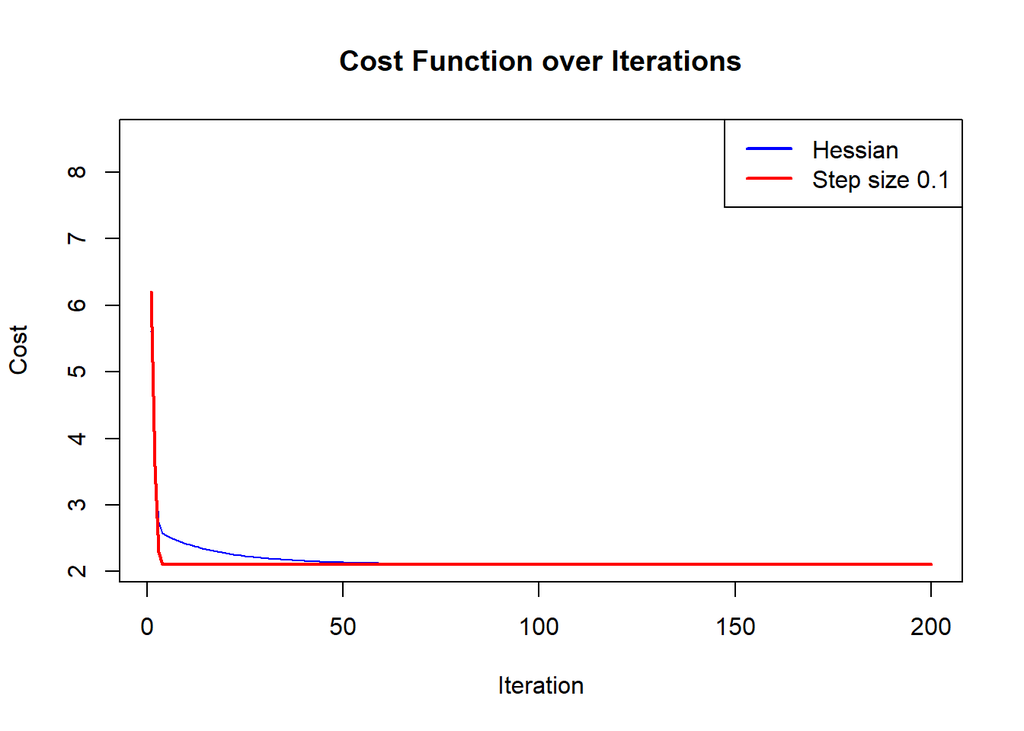

```r
#plot the convergence of the cost from 3.6
plot(result_01$cost, type = "l", col = "blue", ylim = range(c(result_001$cost, result_01$cost, result_025$cost)),
     xlab = "Iteration", ylab = "Cost", main = "Cost Function over Iterations")
lines(result$cost, col = "red", lwd = 2) # add the cost convergence from hessian
legend("topright", legend = c("Hessian", "Step size 0.1"), col = c("blue", "red"), lwd = 2)
```

**Note**

Based on the cost convergence graph, using the same number of iterations, Hessian method converges faster than the gradient with step size 0.1(best performer in 3.6). However, the Hessian model’s estimate heavily depends on how close the initial guess is to the actual result, and can diverge if they are too far away. Although adding a trust region can help overcome the instability because of the distance between initial guess and actual values, the math and coding for Hessian including trust region is more complex, which requires more computing time and power for each iteration. So although the number of iterations may be much fewer than gradient method, the overall time consumed may not differ.

These results is a trade-off in: gradient descent is simpler, more robust to poor initial guesses, and computationally cheaper per step, while the Hessian method converges faster in theory but demands better initialization and higher per-iteration cost.

## 5. Learning parametric models using the optim function

We now turn to how to use powerful built-in functions to carry out optimisation. One such function is `'optim()'`. By default, this function performs minimisation, however, it is straightforward to adapt it for maximisation by multiplying the objective function by $-1$.

The main input to the `'optim()'` function is `'fn'`, which is the function to be optimised. We need to code this function ourselves, and the first argument to this function is what `'optim()'` optimises over (in our case it should be the vector $\beta$). If the function has further inputs, such as in our example when we also need to supply the data, these have to be supplied to the `'optim()'` function too (this is illustrated in the tip to Problem 5.2).

The following code implements the log-likelihood function for the Poisson regression model in two steps. First, the function `'log_dens_Poisson()'` computes the log-density for each of the $n=1000$ observations. Note that this function is vectorised, i.e. it does not use any for-loops, which is much faster. Note also that the function is not assuming a fixed length of the `'beta'` input, so if we have more regression coefficients (more than 1 feature), the code will still function properly. It only requires that the number of columns of `'X'` matches the length of `'beta'`, which is also a requirement in the formulation of the model (Equation 1), so that the dot product is defined. Second, the function `'log_like_Poisson()'` sums the $n=1000$ elements of the vector returned by `'log_dens_Poisson()'`.

```r
log_dens_Poisson <- function(beta, y, X) {
  # log-density for each y_i, X_i
  return(dpois(y, lambda = exp(X%*%beta),log = TRUE))
}

log_like_Poisson <- function(beta, y, X) {
  # log-likelihood (for all observations)
  return(sum(log_dens_Poisson(beta, y, X)))
}
```

#### 💪 Problem 5.1

Code a cost function $J(\beta)$ that uses the vectorised functions above (`'log_dens_Poisson()'` and `'log_like_Poisson()'`).

**Tip**

Although $J(\beta)$ is, in a mathematical sense, a function of $\beta$ only, you have to supply both `'y'` and `'X'` to the R function (because both `'log_dens_Poisson()'` and `'log_like_Poisson()'` require them).

```r
cost_function <- function(beta, y, X){
  n <- length(y)
  return(-1/n*log_like_Poisson(beta, y, X))}
```

#### 💪 Problem 5.2

Use the `'optim()'` function to minimise the objective function $J(\beta)$. Can you retrieve the true parameter values?

**Tip**

The `'optim()'` function has a variety of inputs and you are encouraged to use the `'help()'` function to learn more. This function will become indispensable for you in your future career, so familiarise yourself with it!

A standard way to call the function (assuming the extra arguments to `J` are `y` and `X`) is `'obj<-optim(beta_start, J, method="L-BFGS-B", y=y, X=X)'`, where `'beta_start'` is a vector of starting values, `'J'` is the function to minimise, and `'method'` is the method chosen.

```r
beta <- c(0,0)
x <- as.matrix(cbind(1, x)) # include intercept and make sure that lambda = exp(X%*%beta) is correct
y <- as.numeric(y)

obj <- optim(par = beta, fn = cost_function, method = "L-BFGS-B", y=y, X = x )
cat("Optimal coefficients to minimize the cost function:\nbeta 0: ",obj$par[1], '\nbeta 1: ', obj$par[2])
```

```
Optimal coefficients to minimize the cost function:
beta 0:  0.2556842
beta 1:  2.525073
```

```r
beta <- c(1,1)

obj <- optim(par = beta, fn = cost_function, method = "L-BFGS-B", y=y, X = x )
cat("Optimal coefficients to minimize the cost function:\nbeta 0: ",obj$par[1], '\nbeta 1: ', obj$par[2])
```

```
Optimal coefficients to minimize the cost function:
beta 0:  0.2556135
beta 1:  2.525179
```

**Note**

The result from optim() function is not the true beta, but compared to the betas estimated from other methods used in this assignment, it is close enough and much more simple to implement. We have tried other initial beta, optim() gives different estimates with those initial betas, seems like it also depend on how close the initial guess is to the true values, similar to the Newton method.

In theory:

For a **convex** problem (like least squares or logistic regression), $J(\beta)$ is convex ⇒ unique global minimum.

So regardless of where we start, all optimisation paths should end up at the same optimal $\beta$.

In pratice:

When using numerical optimisation (`optim()`), the algorithm approximates the solution iteratively and stops when certain tolerances are met (gradient norms).

That means:

- It might stop when the gradient is *small enough*, not exactly zero.
- Floating-point rounding or step-size differences can cause small deviations.
- The reported solution is within machine precision of the true optimum, but not exactly identical.

We now turn to estimating a Poisson regression for real data with more features. The dataset `'eBay_Coins.RData'` contains observations from 1000 eBay auctions of coins. The dataset can be downloaded from the Canvas page of the course. The response variable is `'nBids'`, which records the number of bids in each auction. The remaining variables are the following features (including the intercept):

- `'Const'`: Intercept.
- `'PowerSeller'`: Is the seller selling large volumes on eBay?
- `'VerifyID'`: Is the seller verified by eBay?
- `'Sealed'`: Was the coin sold sealed in a never opened envelope?
- `'MinBlem'`: Did the coin have a minor defect?
- `'MajBlem'`: Did the coin have a major defect?
- `'LargNeg'`: Did the seller get a lot of negative feedback from customers?
- `'LogBook'`: Logarithm of the coins book value according to expert sellers. Standardised.
- `'MinBidShare'`: A variable that measures the ratio of the minimum selling price (starting price) to the book value. Standardised.

#### 💪 Problem 5.3

Use the `'optim()'` function to learn the parameters in the Poisson regression model for the eBay dataset. Note that you have to read in the dataset yourself this time.

```r
load("C:/Users/asus/Desktop/Machine learning/Lab 2/eBay_coins.RData")
summary(eBay_coins)
```

```
     nBids            Const    PowerSeller       VerifyID         Sealed
 Min.   : 0.000   Min.   :1   Min.   :0.000   Min.   :0.000   Min.   :0.000
 1st Qu.: 2.000   1st Qu.:1   1st Qu.:0.000   1st Qu.:0.000   1st Qu.:0.000
 Median : 4.000   Median :1   Median :1.000   Median :0.000   Median :0.000
 Mean   : 3.635   Mean   :1   Mean   :0.533   Mean   :0.061   Mean   :0.097
 3rd Qu.: 5.000   3rd Qu.:1   3rd Qu.:1.000   3rd Qu.:0.000   3rd Qu.:0.000
 Max.   :12.000   Max.   :1   Max.   :1.000   Max.   :1.000   Max.   :1.000
    Minblem         MajBlem         LargNeg         LogBook
 Min.   :0.000   Min.   :0.000   Min.   :0.000   Min.   :-1.1506000
 1st Qu.:0.000   1st Qu.:0.000   1st Qu.:0.000   1st Qu.:-0.4608000
 Median :0.000   Median :0.000   Median :0.000   Median :-0.0520000
 Mean   :0.093   Mean   :0.036   Mean   :0.086   Mean   : 0.0000065
 3rd Qu.:0.000   3rd Qu.:0.000   3rd Qu.:0.000   3rd Qu.: 0.5108000
 Max.   :1.000   Max.   :1.000   Max.   :1.000   Max.   : 2.8247000
  MinBidShare
 Min.   :-0.5777000
 1st Qu.:-0.3341000
 Median :-0.0726000
 Mean   :-0.0000022
 3rd Qu.: 0.3253000
 Max.   : 1.1241000
```

```r
y_coins <- eBay_coins$nBids
x_coins <- as.matrix(eBay_coins[, c('Const', 'PowerSeller', 'VerifyID', 'Sealed', 'Minblem', 'MajBlem', 'LargNeg', 'LogBook', 'MinBidShare')])
beta <- rep(0, ncol(x_coins))
coins_beta <- optim(par = beta, fn = cost_function, method = "L-BFGS-B", y=y_coins, X = x_coins)
cat("Beta estimate:\nConst: ", coins_beta$par[1], '\nPowerSeller: ', coins_beta$par[2], '\nVerifyID: ', coins_beta$par[3], '\nSealed: ', coins_beta$par[4], '\nMinblem: ', coins_beta$par[5], '\nMajBlem: ', coins_beta$par[5], '\nLargNeg: ', coins_beta$par[6], '\nLogBook: ', coins_beta$par[7], '\nMinBidShare: ', coins_beta$par[8])
```

[output not shown]

#### 💪 Problem 5.4

Suppose there is a new auction with features:

- `'PowerSeller'=1`,
- `'VerifyID'=1`,
- `'Sealed'=1`,
- `'MinBlem'=0`,
- `'MajBlem'=0`,
- `'LargNeg'=0`,
- `'LogBook'=1`,
- `'MinBidShare'=0.5`.

Provide a point estimate of the expected number of bidders for this auction.

```r
# Expected number of bidders = lambda = exp(sum(beta_i*x_i))
new_auction <- c(1,1,1,1,0,0,0,1,0.5) #added 1 for the intercept
expected_no_bidders <- exp(sum(new_auction*coins_beta$par))
cat("Point estimate of the expected number of bidders: ",expected_no_bidders)
```

```
Point estimate of the expected number of bidders:  1.03398
```

## 6. Deep learning for spam email data (classification)

Recall the `spam_ham_emails.RData` dataset from Computer lab 1 and Part I above. To make Part II of the lab self-contained, we repeat the dataset description. The dataset consists of $n=4601$ spam ($y=1$) and ham (no spam, $y=0$) emails with corresponding 15 features and can be downloaded from the Canvas page of the course[^5].

Most of the features are continuous real variables in the interval $[0, 100]$, with values corresponding to the percentage of occurrence of a specific word or character in the email. There are also a few features that capture the tendency to use many capital letters. The following code standardises the features and creates a partition with 75% of the data for training and 25% for testing. Some important comments follow after the code.

```r
#rm(list=ls()) # Remove variables
#cat("\014") # Clean workspace
load(file = 'C:/Users/asus/Desktop/Machine learning/Lab 2/spam_ham_emails.RData')
set.seed(12345)
suppressMessages(library(caret))
Spam_ham_emails[, -1] <- scale(Spam_ham_emails[, -1]) # standardize the predictors
Spam_ham_emails[, 'spam'] <- as.integer(Spam_ham_emails[, 'spam'] == 1) # convert spam column to 0 and 1 only
head(Spam_ham_emails)
```

```
  spam       over     remove   internet        free        hpl          X.
1    0 -0.3502281 -0.2917622 -0.2625330 -0.30134485  4.2669752 -0.32987644
2    1  1.6583607 -0.2917622  0.4106637  1.03071019 -0.2992074  0.38364598
3    0 -0.3502281 -0.2917622 -0.2625330 -0.30134485  2.6659926 -0.32987644
4    1  0.6358064 -0.2917622 -0.2625330 -0.30134485 -0.2992074 -0.28451505
5    1  0.3436480  0.1936234 -0.2625330 -0.07126262 -0.2992074 -0.06996793
6    1 -0.3502281  0.9855684  0.9841276 -0.30134485 -0.2992074  0.17522878
        X..1   CapRunMax CapRunTotal        our         hp   george      X1999
1 -0.3083214 -0.17021174  0.02096274 -0.4642639  3.9791176 -0.22787  4.9900587
2  0.8751730 -0.08811470  0.01271665 -0.4642639 -0.3287789 -0.22787 -0.3234205
3 -0.3083214 -0.22665345 -0.40618481 -0.4642639 -0.3287789 -0.22787  2.7702052
4 -0.3083214 -0.09837683 -0.12416847 -0.4642639 -0.3287789 -0.22787 -0.3234205
5  0.9239769  0.40959862  0.75651413 -0.1817414 -0.3287789 -0.22787 -0.3234205
6  1.3672790 -0.17021174 -0.05655052  0.6658261 -0.3287789 -0.22787 -0.3234205
           re       edu
1  0.59185916 -0.197366
2 -0.03086294 -0.197366
3 -0.29774385 -0.197366
4 -0.29774385 -0.197366
5 -0.29774385 -0.197366
6 -0.29774385 -0.197366
```

```r
train_obs <- createDataPartition(y = Spam_ham_emails$spam, p = .75, list = FALSE)
train <- as.matrix(Spam_ham_emails[train_obs, ])
y_train <- train[, 1] # first column
X_train <- train[, -1] # all columns except the first column
test <- as.matrix(Spam_ham_emails[-train_obs, ])
y_test <- test[, 1]
X_test <- test[, -1]

# Confirm both training and test are balanced with respect to spam emails
cat("Percentage of training data consisting of spam emails:", 100*mean(train[, 1] == 1))
```

```
Percentage of training data consisting of spam emails: 39.46682
```

```r
cat("Percentage of test data consisting of spam emails:", 100*mean(test[, 1] == 1))
```

```
Percentage of test data consisting of spam emails: 39.21739
```

Note that in the code above, **we are not defining the response variable as a factor variable** like we did in Computer lab 1 and Part I above, because the `keras` package that we will use does not recognise factor variables (the package originated in Python). For the same reason, it does not recognise the data frame structure in R, and therefore we use the `as.matrix()` function to convert it to a matrix object.

**Be aware!**

Not ensuring that the inputs to functions in the `keras` package have the correct format will cause painful and time consuming bugs.

In this problem we use neural networks, also known as deep learning, to classify spam emails via the `keras` package. Keras is an open-source deep learning framework originally developed in Python but extended to work with R. The package allows you to build, fit, and evaluate deep learning models with a variety of networks.

It requires some effort to install `keras` in R, particularly on Windows. An alternative Python notebook is provided if you cannot manage to install `keras` in R (`keras` is much easier to install in Python). However, I do encourage you to give it a try to install it in R and here follow some (hopefully!) useful instructions. You will need programs that allow compiling source code. On Windows, `RTools` allows compilation of source code. The corresponding program on Mac is `Xcode`; see this [page](https://clanfear.github.io/CSSS508/docs/compiling.html%60) for some helpful instructions. After installation of these programs, you have to install the `tensorflow` package and make sure Python is installed on your system; see this [page](https://tensorflow.rstudio.com/install/) for some helpful instructions. For Windows, another suggestion is to install `anaconda3` and then install a new version of Rstudio through the conda environment (using the Anaconda navigator); see this page for more information [page](https://github.com/rstudio/keras3/issues/649). Another tip that may be useful can be found on this [page](https://github.com/rstudio/keras3/issues/1381).

If the instructions above do not work, try searching online for alternate solutions or ask an AI tool for help. If you still cannot manage to install the `keras` package in R, I recommend that you do the deep learning part of the lab in Python. A separate Python notebook is available on Canvas for this purpose.

The whole process above uses operations that require administrative privileges on the computer, thus making the `keras` package not readily available on the work stations in the computer lab room. You should therefore use your own laptop to solve problems when working with the `keras` package. If you do not have access to a laptop, or a private work station with administrative rights, let me know ASAP.

The following codes install tensorflow package via anaconda. I will use keras 3 instead of keras to match with my python version

```r
suppressMessages(library(tensorflow))
suppressMessages(library(keras3)) #using keras 3 instead of keras to match with my version of python
```

The following code builds a simple two layer dense neural network. Some explanation of the code follows.

```r
tensorflow::tf$random$set_seed(12345)
model <- keras_model_sequential()
model %>%
  # Add first hidden layer
  layer_dense(units = 12, activation = 'relu', input_shape = c(15)) %>%
  # Add regularisation via dropout to the first hidden layer
  layer_dropout(rate = 0.3) %>%
  # Add second hidden layer
  layer_dense(units = 6, activation = 'relu') %>%
  # Add regularisation via dropout to the second hidden layer
  layer_dropout(rate = 0.3) %>%
  # Add layer that connects to the observations
  layer_dense(units = 1, activation = 'sigmoid')
summary(model)
```

```
Model: "sequential"
┌───────────────────────────────────┬──────────────────────────┬───────────────
│ Layer (type)                      │ Output Shape             │       Param #
├───────────────────────────────────┼──────────────────────────┼───────────────
│ dense (Dense)                     │ (None, 12)               │           192
├───────────────────────────────────┼──────────────────────────┼───────────────
│ dropout (Dropout)                 │ (None, 12)               │             0
├───────────────────────────────────┼──────────────────────────┼───────────────
│ dense_1 (Dense)                   │ (None, 6)                │            78
├───────────────────────────────────┼──────────────────────────┼───────────────
│ dropout_1 (Dropout)               │ (None, 6)                │             0
├───────────────────────────────────┼──────────────────────────┼───────────────
│ dense_2 (Dense)                   │ (None, 1)                │             7
└───────────────────────────────────┴──────────────────────────┴───────────────
 Total params: 277 (1.08 KB)
 Trainable params: 277 (1.08 KB)
 Non-trainable params: 0 (0.00 B)
```

The `tensorflow` package is needed to set the seed for reproducibility on the third line (the usual `set.seed()` call does not work in `keras`). The `%>%` operator is called the pipe operator. It is a useful operator that allows you to chain together multiple calls in a concise and readable way. The pipe operator takes the output of the left-hand side expression and passes it as the first argument to the right-hand side expression.

The `keras_model_sequential()` function initialises an empty model that we can stack layers on. The first (from the left) call `layer_dense()` stacks the first dense (i.e. fully connected) layer with 12 units (specified by the argument `units`) to the model. Since this is the first layer, the dimension of the input has to be specified via the argument `input`. Note that our feature matrix does not contain the intercept and thus has dimension 15. Importantly, `layer_dense()` includes an intercept by default via the argument `use_bias=TRUE` (recall that bias means intercept in the deep learning world). **It is therefore important to always omit the intercept term in the feature matrix** (unless `use_bias=FALSE` is set in the first layer, however, this is unusual to do). The `activation` argument to the `layer_dense()` function specifies the activation function for the corresponding layer. Next, the call `layer_dropout()` adds regularisation (to prevent overfitting) via dropout to the preceding layer, where the `rate` argument specifies the fraction of neurons (units) to randomly dropout (set to zero) during training in the corresponding layer. Finally, the `summary()` function summarises the object.

The model above is said to have two (hidden) layers; the last layer only connects to the output. Following the notation in Lindholm et al. (2022)[^6], the model specified above has the structure with activation functions ReLU $h$ and sigmoid $g$.

**Note**

$$\begin{align*}
\boldsymbol{q}^{(1)} & =h\left(\boldsymbol{W}^{(1)}\mathbf{x}+\boldsymbol{b}^{(1)}\right)\\
\boldsymbol{q}^{(2)} & =h\left(\boldsymbol{W}^{(2)}\boldsymbol{q}^{(1)}+\boldsymbol{b}^{(2)}\right)\\
\Pr(y =1|\mathbf{x}) & = g\left(\boldsymbol{W}^{(3)}\boldsymbol{q}^{(2)}+b^{(3)}\right)
\end{align*}$$

#### 💪 Problem 6.1

What are the dimensions of $\boldsymbol{q}^{(1)},\boldsymbol{q}^{(2)}, \boldsymbol{b}^{(1)},\boldsymbol{b}^{(2)}, b^{(3)}, \boldsymbol{W}^{(1)}, \boldsymbol{W}^{(2)}, \boldsymbol{W}^{(3)}$, and $\Pr(y =1|\mathbf{x})$?

**Note**

$\boldsymbol{q}^{(1)} =h\left(\boldsymbol{W}^{(1)}\mathbf{x}+\boldsymbol{b}^{(1)}\right)$

$\boldsymbol{W}^{(1)}$ needs to map 15 features for 12 neurons $\rightarrow \boldsymbol{W}^{(1)} \in \mathbb{R}^{12 \times 15}$

$\boldsymbol{b}^{(1)}$ is 1 bias for each neuron in layer 1 $\rightarrow \boldsymbol{b}^{(1)} \in \mathbb{R}^{12}$ $\boldsymbol{q}^{(1)}$ is the output for each neuron in layer 1 $\rightarrow \boldsymbol{q}^{(1)} \in \mathbb{R}^{12}$

$\boldsymbol{q}^{(2)} =h\left(\boldsymbol{W}^{(2)}\boldsymbol{q}^{(1)}+\boldsymbol{b}^{(2)}\right)$

$\boldsymbol{W}^{(2)}$ needs to map 12 inputs for 6 neurons $\rightarrow \boldsymbol{W}^{(2)} \in \mathbb{R}^{6 \times 12}$ $\boldsymbol{b}^{(2)}$ is 1 bias for each neuron in layer 2 $\rightarrow \boldsymbol{b}^{(2)} \in \mathbb{R}^{6}$

$\boldsymbol{q}^{(2)}$ is the output for each neuron in layer 2 $\rightarrow \boldsymbol{q}^{(2)} \in \mathbb{R}^{6}$

$\Pr(y =1|\mathbf{x}) = g\left(\boldsymbol{W}^{(3)}\boldsymbol{q}^{(2)}+b^{(3)}\right)$

$\boldsymbol{W}^{(3)}$ needs to map 6 inputs for 1 neuron $\rightarrow \boldsymbol{W}^{(3)} \in \mathbb{R}^{1 \times 6}$

$\boldsymbol{b}^{(3)}$ is 1 bias for 1 neuron in layer 3$\rightarrow \boldsymbol{b}^{(3)} \in \mathbb{R}$ (it’s a scalar)

$\Pr(y =1|\mathbf{x})$ is a probability, which is a scalar $\in \mathbb{R}$

#### 💪 Problem 6.2

What is the number of parameters for each of the three equations above ($\mathbf{x}$ and $\boldsymbol{q}$ are not parameters)? Verify that this agrees with the output of `summary(model)` above.

**Note**

$\boldsymbol{q}^{(1)} =h\left(\boldsymbol{W}^{(1)}\mathbf{x}+\boldsymbol{b}^{(1)}\right)$ has 15 (feature) x 12 (neuron in layer 1) + 12 (bias) = 192 (parameter)

$\boldsymbol{q}^{(2)} =h\left(\boldsymbol{W}^{(2)}\mathbf{x}+\boldsymbol{b}^{(2)}\right)$ similarly, this has $12 \times 6 + 6 = 78$ parameters

$\Pr(y =1|\mathbf{x}) = g\left(\boldsymbol{W}^{(3)}\boldsymbol{q}^{(2)}+b^{(3)}\right)$ this has $6 +1 =7$ parameters

In total, there are $192 + 78 + 7 = 277$ parameters, which agrees with the output of `summary(model)` above.

We now compile the model.

```r
model %>% compile(loss = 'binary_crossentropy', optimizer = 'SGD', metrics = c('accuracy', 'AUC'))
```

The argument `loss` specifies the objective function to minimise when learning the algorithm. Since this a binary classification problem we use the binary crossentropy (recall that crossentropy is related to the likelihood; it is the negative average log-likelihood function). If we instead deal with a multi-class classification problem, the categorical crossentropy is an option, specified as `loss='categorical_crossentropy'` . For a regression problem, on the other hand, `loss='mse'` (mean squared error) is appropriate. The argument `optimizer='SGD'` uses the optimiser stochastic gradient descent (covered in Part I above). More advanced optimisers such as `'RMSprop'` or `'adam'` can be used. Finally, the argument `metrics` specifies the metrics used to evaluate the performance of the model. The metrics are calculated after each epoch of training, and thus track the progress of the model fitting.

The following code fits the model running the stochastic optimiser for 200 epochs with a mini-batch size of 50. The `validation_split` argument specifies the ratio of the training data used to compute the validation metrics.

```r
model_fit <- model%>%fit(X_train, y_train, epochs = 200, batch_size = 50, validation_split = 0.2, verbose = 0)
# validation split: 20% of the training data is used to validate the model, not to train
```

```r
early_stopping <- callback_early_stopping(monitor="val_loss", patience = 10, restore_best_weights = TRUE)
```

The argument `monitor` specifies which quantity is monitored to determine if early stopping should occur. The argument `patience=10` executes the early stopping if there is no improvement in the monitored quantity for 10 consecutive epochs. Finally, `restore_best_weights=TRUE` restores the weights (parameters) from the epoch with the best value of the monitored quantity (if `FALSE` the weights from the last step are used). We now show how the callback is used to allow for (possibly) early stopping. For illustration purposes, the code creates a new model instance, since otherwise the `fit()` function will resume the optimisation where the previous call to `fit()` left off. Moreover, the optimiser ADAM is used (in place of SGD).

```r
tensorflow::tf$random$set_seed(12345)
model <- keras_model_sequential()
model %>%
  # Add first hidden layer
  layer_dense(units = 12, activation = 'relu', input_shape = c(15)) %>%
  # Add regularisation via dropout to the first hidden layer
  layer_dropout(rate = 0.3) %>%
  # Add second hidden layer
  layer_dense(units = 6, activation = 'relu') %>%
  # Add regularisation via dropout to the second hidden layer
  layer_dropout(rate = 0.3) %>%
  # Add layer that connects to the observations
  layer_dense(units = 1, activation = 'sigmoid')
summary(model)
```

```
Model: "sequential_1"
┌───────────────────────────────────┬──────────────────────────┬───────────────
│ Layer (type)                      │ Output Shape             │       Param #
├───────────────────────────────────┼──────────────────────────┼───────────────
│ dense_3 (Dense)                   │ (None, 12)               │           192
├───────────────────────────────────┼──────────────────────────┼───────────────
│ dropout_2 (Dropout)               │ (None, 12)               │             0
├───────────────────────────────────┼──────────────────────────┼───────────────
│ dense_4 (Dense)                   │ (None, 6)                │            78
├───────────────────────────────────┼──────────────────────────┼───────────────
│ dropout_3 (Dropout)               │ (None, 6)                │             0
├───────────────────────────────────┼──────────────────────────┼───────────────
│ dense_5 (Dense)                   │ (None, 1)                │             7
└───────────────────────────────────┴──────────────────────────┴───────────────
 Total params: 277 (1.08 KB)
 Trainable params: 277 (1.08 KB)
 Non-trainable params: 0 (0.00 B)
```

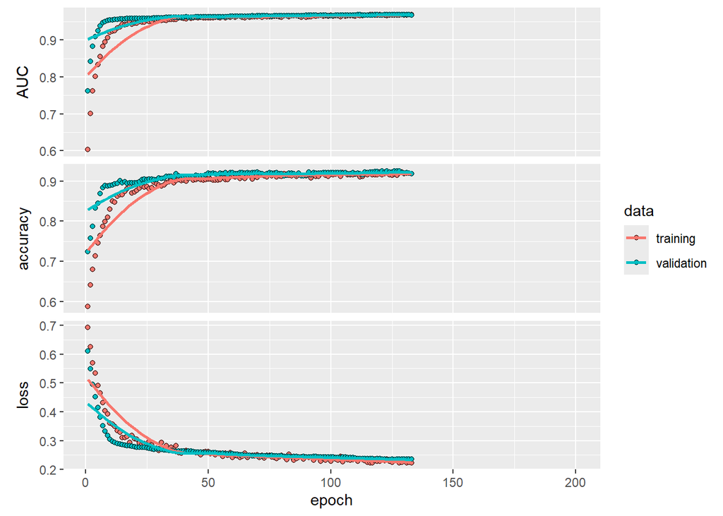

```r
# Compile model
model %>% compile(loss = 'binary_crossentropy', optimizer = 'adam', metrics = c('accuracy', 'AUC'))
# Fit model
model_fit <- model %>% fit(X_train, y_train, epochs = 200, batch_size = 50, validation_split = 0.2, callbacks = list(early_stopping), verbose = 0)
plot(model_fit)
```

```r
print(length(model_fit$metrics$val_loss)) # how many epochs before early stopping
```

```
[1] 133
```

Another way of imposing model regularisation is via an explicit penalty, e.g. L1 or L2 penalty, on the model coefficients. The following code applies an L1 penalty on the first hidden layer of the model (in addition to the regularisation by dropout).

```r
tensorflow::tf$random$set_seed(12345)
model_l1_reg <- keras_model_sequential()
model_l1_reg %>%
  # Add first hidden layer
  layer_dense(units = 12, activation = 'relu', input_shape = c(15), kernel_regularizer = regularizer_l1(l=0.01)) %>%
  # Add regularisation via dropout to the first hidden layer
  layer_dropout(rate = 0.3) %>%
  # Add second hidden layer
  layer_dense(units = 6, activation = 'relu') %>%
  # Add regularisation via dropout to the second hidden layer
  layer_dropout(rate = 0.3) %>%
  # Add layer that connects to the observations
  layer_dense(units = 1, activation = 'sigmoid')
summary(model_l1_reg)
```

```
Model: "sequential_2"
┌───────────────────────────────────┬──────────────────────────┬───────────────
│ Layer (type)                      │ Output Shape             │       Param #
├───────────────────────────────────┼──────────────────────────┼───────────────
│ dense_6 (Dense)                   │ (None, 12)               │           192
├───────────────────────────────────┼──────────────────────────┼───────────────
│ dropout_4 (Dropout)               │ (None, 12)               │             0
├───────────────────────────────────┼──────────────────────────┼───────────────
│ dense_7 (Dense)                   │ (None, 6)                │            78
├───────────────────────────────────┼──────────────────────────┼───────────────
│ dropout_5 (Dropout)               │ (None, 6)                │             0
├───────────────────────────────────┼──────────────────────────┼───────────────
│ dense_8 (Dense)                   │ (None, 1)                │             7
└───────────────────────────────────┴──────────────────────────┴───────────────
 Total params: 277 (1.08 KB)
 Trainable params: 277 (1.08 KB)
 Non-trainable params: 0 (0.00 B)
```

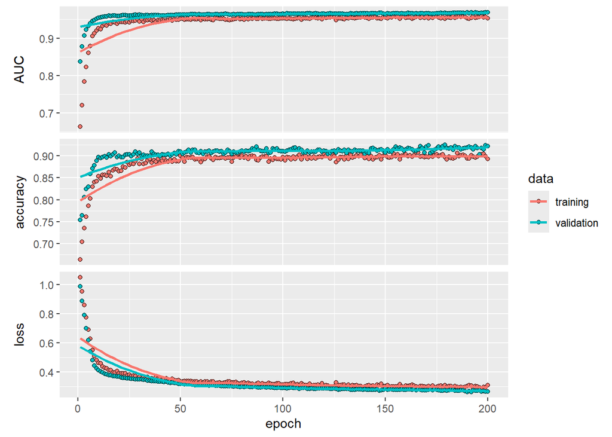

```r
# Early stopping
early_stopping <- callback_early_stopping(monitor="val_loss", patience = 10, restore_best_weights = TRUE)
# Compile model
model_l1_reg %>% compile(loss = 'binary_crossentropy', optimizer = 'adam', metrics = c('accuracy', 'AUC'))
# Fit model
model_fit_l1_reg <- model_l1_reg %>% fit(X_train, y_train, epochs = 200, batch_size = 50, validation_split = 0.2, verbose = 0)
plot(model_fit_l1_reg)
```

The argument `kernel_regularizer` regularises the weights (kernel is synonym for weights in deep learning jargon). It is also possible to regularise the bias (the intercept) via the argument `bias_regularizer`, however, this is less common for obvious reasons. The `regularizer_l1()` function applies L1 regularisation and its argument `l` controls the amount of regularisation (a larger value regularises more, i.e. gives a less flexible model). Other regularisations can also be applied, such as L2 (e.g. `regularizer_l2(l=0.01)`) or the elastic net penalty (e.g. `regularizer_l1_l2(l1=0.01, l2=0,01)`). Finally, note that the other layers in the model can also be regularised.

Our final demonstration in this section concerns how to carry out model evaluation and predictions. The same concepts for evaluating classifiers will be used, e.g. the accuracy, confusion matrix, and ROC curve (among others). Note that the `confusionMatrix()` function requires factor variables as input, which is achieved by using the `as.factor()` function.

```r
suppressMessages(library(pROC))
suppressMessages(library(caret))
# Evaluating on training data
results_train_model <- model %>% evaluate(X_train, y_train)
```

```
108/108 - 0s - 3ms/step - AUC: 0.9770 - accuracy: 0.9342 - loss: 0.1916
```

```r
print("2-Layer model")
```

```
[1] "2-Layer model"
```

```r
print(results_train_model)
```

```
$AUC
[1] 0.9769751

$accuracy
[1] 0.934222

$loss
[1] 0.1916445
```

```r
# Evaluating on test data
results_test_model <- model %>% evaluate(X_test, y_test)
```

```
36/36 - 0s - 3ms/step - AUC: 0.9714 - accuracy: 0.9313 - loss: 0.1976
```

```r
print(results_test_model)
```

```
$AUC
[1] 0.9713909

$accuracy
[1] 0.9313043

$loss
[1] 0.197603
```

```r
# Prediction test data
y_prob_hat_test <- model %>% predict(X_test)
```

```
36/36 - 0s - 4ms/step
```

```r
threshold <- 0.5 # Predict spam if probability > threshold
y_hat_test <- as.factor(y_prob_hat_test > threshold)
levels(y_hat_test) <- c("not spam", "spam")
test_spam <- as.factor(test[, 1])
levels(test_spam) <- c("not spam", "spam")
confusionMatrix(data = y_hat_test, test_spam, positive = "spam")
```

```
Confusion Matrix and Statistics

          Reference
Prediction not spam spam
  not spam      665   45
  spam           34  406

               Accuracy : 0.9313
                 95% CI : (0.9151, 0.9452)
    No Information Rate : 0.6078
    P-Value [Acc > NIR] : <2e-16

                  Kappa : 0.8553

 Mcnemar's Test P-Value : 0.2606

            Sensitivity : 0.9002
            Specificity : 0.9514
         Pos Pred Value : 0.9227
         Neg Pred Value : 0.9366
             Prevalence : 0.3922
         Detection Rate : 0.3530
   Detection Prevalence : 0.3826
      Balanced Accuracy : 0.9258

       'Positive' Class : spam
```

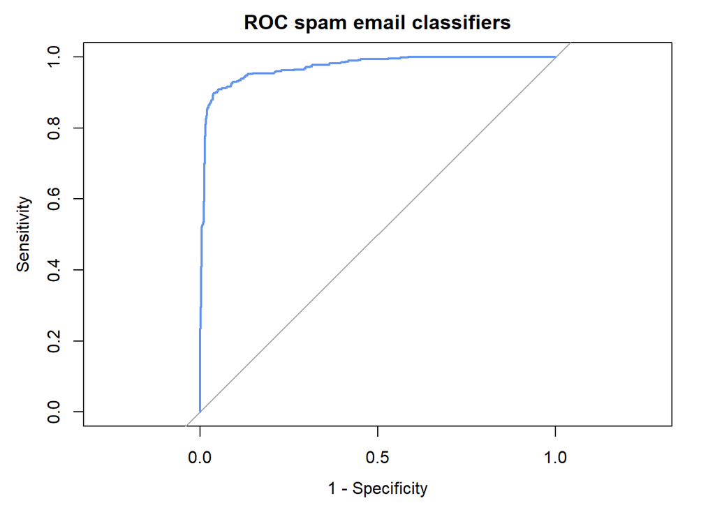

```r
# ROC curve
roc_obj <- roc(response = test_spam, predictor = as.vector(y_prob_hat_test), print.auc = TRUE)
plot(roc_obj, legacy.axes = TRUE, col = "cornflowerblue", main = "ROC spam email classifiers")
```

```r
cat("AUC for deep learning 2 hidden layer model", roc_obj$auc)
```

```
AUC for deep learning 2 hidden layer model 0.971486
```

#### 💪 Problem 6.3

Fit a one layer dense neural network with 8 hidden units to the spam data using the ADAM optimiser. You can use the same settings as the previous problem, but feel free to experiment. How does this model compare to the two layer dense model above?

```r
# Build a 1 hidden layer neural network
tensorflow::tf$random$set_seed(0)
model_6.3 <- keras_model_sequential()
model_6.3 %>%
  # Add ONE hidden layer
  layer_dense(units = 8, activation = 'relu', input_shape = c(15)) %>%
  # Add regularisation via dropout to the first hidden layer
  layer_dropout(rate = 0.3) %>%
  # Add layer that connects to the observations
  layer_dense(units = 1, activation = 'sigmoid')
summary(model_6.3)
```

```
Model: "sequential_3"
┌───────────────────────────────────┬──────────────────────────┬───────────────
│ Layer (type)                      │ Output Shape             │       Param #
├───────────────────────────────────┼──────────────────────────┼───────────────
│ dense_9 (Dense)                   │ (None, 8)                │           128
├───────────────────────────────────┼──────────────────────────┼───────────────
│ dropout_6 (Dropout)               │ (None, 8)                │             0
├───────────────────────────────────┼──────────────────────────┼───────────────
│ dense_10 (Dense)                  │ (None, 1)                │             9
└───────────────────────────────────┴──────────────────────────┴───────────────
 Total params: 137 (548.00 B)
 Trainable params: 137 (548.00 B)
 Non-trainable params: 0 (0.00 B)
```

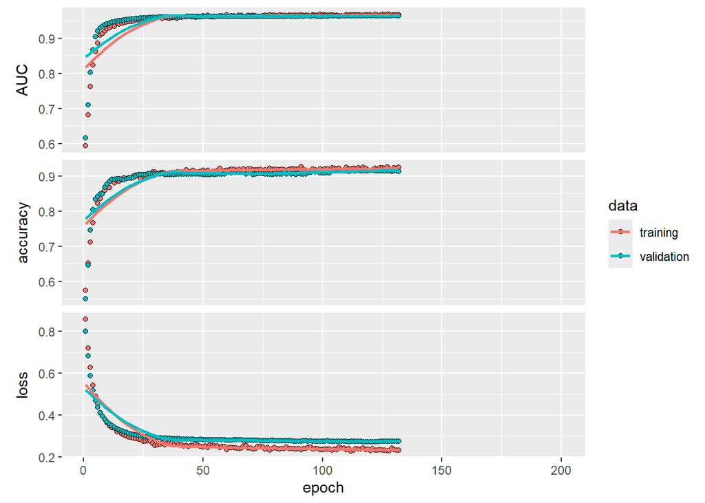

```r
# Compile model
model_6.3 %>% compile(loss = 'binary_crossentropy', optimizer = 'adam', metrics = c('accuracy', 'AUC'))
# Early stopping
early_stopping <- callback_early_stopping(monitor="val_loss", patience = 10, restore_best_weights = TRUE)
# Fit model
model_fit_6.3 <- model_6.3 %>% fit(X_train, y_train, epochs = 200, batch_size = 50, validation_split = 0.2, callbacks = list(early_stopping), verbose = 0)
plot(model_fit_6.3)
```

```r
# Evaluating on training data
results_train_model_6.3 <- model_6.3 %>% evaluate(X_train, y_train)
```

```
108/108 - 0s - 2ms/step - AUC: 0.9725 - accuracy: 0.9270 - loss: 0.2185
```

```r
cat("1-Layer model train evaluation \n")
```

```
1-Layer model train evaluation
```

```r
print(results_train_model_6.3)
```

```
$AUC
[1] 0.9724711

$accuracy
[1] 0.9269777

$loss
[1] 0.2184809
```

```r
# Evaluating on test data
results_test_model_6.3 <- model_6.3 %>% evaluate(X_test, y_test)
```

```
36/36 - 0s - 3ms/step - AUC: 0.9682 - accuracy: 0.9296 - loss: 0.2180
```

```r
cat("1-Layer model test evaluation: \n")
```

```
1-Layer model test evaluation:
```

```r
print(results_test_model_6.3)
```

```
$AUC
[1] 0.968222

$accuracy
[1] 0.9295652

$loss
[1] 0.2180324
```

```r
# Prediction test data
y_prob_hat_test_6.3 <- model_6.3 %>% predict(X_test)
```

```
36/36 - 0s - 3ms/step
```

```r
threshold <- 0.5 # Predict spam if probability > threshold
y_hat_test_6.3 <- as.factor(y_prob_hat_test_6.3 > threshold) # convert prob to factors 0, 1
levels(y_hat_test_6.3) <- c("not spam", "spam") # convert levels from 0, 1 to not spam, spam
test_spam <- as.factor(test[, 1]) # convert actual y to factors 0, 1
levels(test_spam) <- c("not spam", "spam") # convert levels from 0, 1 to not spam, spam
confusionMatrix(data = y_hat_test_6.3, test_spam, positive = "spam")
```

```
Confusion Matrix and Statistics

          Reference
Prediction not spam spam
  not spam      665   47
  spam           34  404

               Accuracy : 0.9296
                 95% CI : (0.9132, 0.9437)
    No Information Rate : 0.6078
    P-Value [Acc > NIR] : <2e-16

                  Kappa : 0.8515

 Mcnemar's Test P-Value : 0.1824

            Sensitivity : 0.8958
            Specificity : 0.9514
         Pos Pred Value : 0.9224
         Neg Pred Value : 0.9340
             Prevalence : 0.3922
         Detection Rate : 0.3513
   Detection Prevalence : 0.3809
      Balanced Accuracy : 0.9236

       'Positive' Class : spam
```

[figure not shown]

```r
# ROC curve
roc_obj_6.3 <- roc(response = test_spam, predictor = as.vector(y_prob_hat_test_6.3), print.auc = TRUE)
plot(roc_obj, legacy.axes = TRUE, col = "cornflowerblue", main = "ROC spam email classifiers 6.3")
```

```r
cat("AUC for deep learning 1 hidden layer model", roc_obj_6.3$auc)
```

```
AUC for deep learning 1 hidden layer model 0.9683964
```

**Note**

Moreover, as the model gets more complex and sensitive, it may catch up on noise more, so the trade off needs to be carefully considered in this case.

We didn’t use any regularizers, other than layer dropout, as we wanted to see how the performance changes when the model is significantly simplified. In this case, simplifying the model almost doesn’t cost any performance downgrade in exchange.

With more complex data, fine tuning regularizers can keep the same performance or improve it even though the model is less complex and requires less computational expenses.

## 7. Deep learning for bike rental data (regression)

Recall the `bike_rental_hourly.csv` dataset from Computer lab 1 and Part I above. The dataset can be downloaded from the Canvas page of the course[^7]. To make Part II of the lab self-contained, we repeat the dataset description.

The dataset contains 17379 hourly observations over the two-year period January 1, 2011 - December 31, 2012. The dataset contains many features that may be useful for predicting the number of rides, such as the hour of the day, temperature, humidity, season, weekday, etc. In this section, we use the dataset that in addition contains features that capture the time series characteristics of the data. The following code builds that dataset, where we use the same training and test data as in Problem 4.2 in Computer lab 1. A minor difference is that we are not including the intercept in the feature matrix, since we will use `keras`.

```r
#rm(list=ls()) # Remove variables
#cat("\014") # Clean workspace
suppressMessages(library(dplyr))
suppressMessages(library(splines))
bike_data <- read.csv('C:/Users/asus/Desktop/Machine learning/Lab 2/bike_rental_hourly.csv')
head(bike_data)
```

```
  instant     dteday season yr mnth hr holiday weekday workingday weathersit
1       1 2011-01-01      1  0    1  0       0       6          0          1
2       2 2011-01-01      1  0    1  1       0       6          0          1
3       3 2011-01-01      1  0    1  2       0       6          0          1
4       4 2011-01-01      1  0    1  3       0       6          0          1
5       5 2011-01-01      1  0    1  4       0       6          0          1
6       6 2011-01-01      1  0    1  5       0       6          0          2
  temp  atemp  hum windspeed casual registered cnt
1 0.24 0.2879 0.81    0.0000      3         13  16
2 0.22 0.2727 0.80    0.0000      8         32  40
3 0.22 0.2727 0.80    0.0000      5         27  32
4 0.24 0.2879 0.75    0.0000      3         10  13
5 0.24 0.2879 0.75    0.0000      0          1   1
6 0.24 0.2576 0.75    0.0896      0          1   1
```

```r
bike_data$log_cnt <- log(bike_data$cnt)
bike_data$hour <- bike_data$hr/23 # transform [0, 23] to [0, 1]. 0 is midnight, 1 is 11 PM

# One hot for weathersit
one_hot_encode_weathersit <- model.matrix(~ as.factor(weathersit) - 1,data = bike_data)
one_hot_encode_weathersit  <- one_hot_encode_weathersit[, -1] # Remove reference category
colnames(one_hot_encode_weathersit) <- c('cloudy', 'light rain', 'heavy rain')
bike_data <- cbind(bike_data, one_hot_encode_weathersit)

# One hot for weekday
one_hot_encode_weekday <- model.matrix(~ as.factor(weekday) - 1,data = bike_data)
one_hot_encode_weekday  <- one_hot_encode_weekday[, -1] # Remove reference category
colnames(one_hot_encode_weekday) <- c('Mon', 'Tue', 'Wed', 'Thu', 'Fri', 'Sat')
bike_data <- cbind(bike_data, one_hot_encode_weekday)

# One hot for weekday
one_hot_encode_season <- model.matrix(~ as.factor(season) - 1,data = bike_data)
one_hot_encode_season  <- one_hot_encode_season[, -1] # Remove reference category
colnames(one_hot_encode_season) <- c('Spring', 'Summer', 'Fall')
bike_data <- cbind(bike_data, one_hot_encode_season)

# Create lags
bike_data_new <- mutate(bike_data, lag1 = lag(log_cnt, 1), lag2 = lag(log_cnt, 2),
                        lag3 = lag(log_cnt, 3), lag4 = lag(log_cnt, 4), lag24 = lag(log_cnt, 24))

bike_data_new <- bike_data_new[-c(1:24),] # Lost 24 obs because of lagging

# Create training and test data
bike_all_data_train <- bike_data_new[bike_data_new$dteday >= as.Date("2011-01-01") & bike_data_new$dteday <=  as.Date("2012-05-31"), ]
bike_all_data_test <- bike_data_new[bike_data_new$dteday >= as.Date("2012-06-01") & bike_data_new$dteday <=  as.Date("2012-12-31"), ]
X_train <- bike_all_data_train[, c("lag1", "lag2",  "lag3", "lag4", "lag24")]
spline_basis <- ns(bike_all_data_train$hour, df = 10, intercept = FALSE)
X_train <- cbind(X_train, spline_basis)
colnames(X_train)[1] <- "intercept"
knots <- attr(spline_basis, "knots")
variables_to_keep_in_X <- c("yr", "holiday", "workingday", "temp", "atemp", "hum", "windspeed")
variables_to_keep_in_X <- c(variables_to_keep_in_X, colnames(one_hot_encode_weathersit), colnames(one_hot_encode_weekday), colnames(one_hot_encode_season))
X_train <- cbind(X_train, bike_all_data_train[, variables_to_keep_in_X])
head(X_train)
```

```
   intercept     lag2     lag3     lag4    lag24          1          2
25  3.663562 3.332205 3.526361 3.583519 2.772589 0.00000000 0.00000000
26  2.833213 3.663562 3.332205 3.526361 3.688879 0.01785714 0.00000000
27  2.833213 2.833213 3.663562 3.332205 3.465736 0.14285714 0.00000000
28  2.197225 2.833213 2.833213 3.663562 2.564949 0.41785714 0.01428571
29  1.791759 2.197225 2.833213 2.833213 0.000000 0.62857143 0.11428571
30  1.098612 1.791759 2.197225 2.833213 0.000000 0.34285714 0.58095238
            3 4 5 6 7            8           9           10 yr holiday
25 0.00000000 0 0 0 0  0.000000000 0.000000000  0.000000000  0       0
26 0.00000000 0 0 0 0 -0.116963312 0.350889936 -0.233926624  0       0
27 0.00000000 0 0 0 0 -0.175067667 0.525203001 -0.350135334  0       0
28 0.00000000 0 0 0 0 -0.138695850 0.416087550 -0.277391700  0       0
29 0.00000000 0 0 0 0 -0.065197614 0.195592842 -0.130395228  0       0
30 0.06666667 0 0 0 0 -0.002414726 0.007244179 -0.004829453  0       0
   workingday temp  atemp  hum windspeed cloudy light rain heavy rain Mon Tue
25          0 0.46 0.4545 0.88    0.2985      1          0          0   0   0
26          0 0.44 0.4394 0.94    0.2537      1          0          0   0   0
27          0 0.42 0.4242 1.00    0.2836      1          0          0   0   0
28          0 0.46 0.4545 0.94    0.1940      1          0          0   0   0
29          0 0.46 0.4545 0.94    0.1940      1          0          0   0   0
30          0 0.42 0.4242 0.77    0.2985      0          1          0   0   0
   Wed Thu Fri Sat Spring Summer Fall
25   0   0   0   0      0      0    0
26   0   0   0   0      0      0    0
27   0   0   0   0      0      0    0
28   0   0   0   0      0      0    0
29   0   0   0   0      0      0    0
30   0   0   0   0      0      0    0
```

```r
# Training data
X_train <- as.matrix(X_train)
y_train <- bike_all_data_train$log_cnt
# Test data
y_test <- bike_all_data_test$log_cnt
X_test <- bike_all_data_test[, c("lag1", "lag2",  "lag3", "lag4", "lag24")]
spline_basis_test <- ns(bike_all_data_test$hour, df=10, knots=knots, intercept = FALSE)
X_test <- cbind(X_test, spline_basis_test)
colnames(X_test)[1] <- "intercept"
X_test <- cbind(X_test, bike_all_data_test[, variables_to_keep_in_X])
X_test <- as.matrix(X_test)
```

#### 💪 Problem 7.1

Fit a deep learning model with three hidden layers to the bike rental data. The number of units should be, for each level respectively, 16 (first hidden layer), 8, and 4 (last hidden level). Use ReLU activation functions in all layers. You are free to choose optimisation method and settings, and you may add regularisation via dropout and/or early stopping and/or penalty.

**Tip**

Do not just copy code from Problem 6 without thinking about the settings you need to specify. Keep in mind that this is a regression problem (and not a classification problem!).

```r
tensorflow::tf$random$set_seed(0)

# Create a 3-layer neural network
model_7.1 <- keras_model_sequential()
model_7.1%>%
  # Layer 1
  layer_dense(units = 16, activation = 'relu', input_shape = c(34)) %>%
  layer_dropout(rate = 0.3) %>%
  # Layer 2
  layer_dense(units = 8, activation = 'relu') %>%
  layer_dropout(rate = 0.3) %>%
  # Layer 3
  layer_dense(units = 4, activation = 'relu') %>%
  layer_dropout(rate = 0.3) %>%
  # Output
  layer_dense(units = 1, activation = 'relu') #output the number of rentals in 1 specific hour

# Model summary
summary(model_7.1)
```

```
Model: "sequential_4"
┌───────────────────────────────────┬──────────────────────────┬───────────────
│ Layer (type)                      │ Output Shape             │       Param #
├───────────────────────────────────┼──────────────────────────┼───────────────
│ dense_11 (Dense)                  │ (None, 16)               │           560
├───────────────────────────────────┼──────────────────────────┼───────────────
│ dropout_7 (Dropout)               │ (None, 16)               │             0
├───────────────────────────────────┼──────────────────────────┼───────────────
│ dense_12 (Dense)                  │ (None, 8)                │           136
├───────────────────────────────────┼──────────────────────────┼───────────────
│ dropout_8 (Dropout)               │ (None, 8)                │             0
├───────────────────────────────────┼──────────────────────────┼───────────────
│ dense_13 (Dense)                  │ (None, 4)                │            36
├───────────────────────────────────┼──────────────────────────┼───────────────
│ dropout_9 (Dropout)               │ (None, 4)                │             0
├───────────────────────────────────┼──────────────────────────┼───────────────
│ dense_14 (Dense)                  │ (None, 1)                │             5
└───────────────────────────────────┴──────────────────────────┴───────────────
 Total params: 737 (2.88 KB)
 Trainable params: 737 (2.88 KB)
 Non-trainable params: 0 (0.00 B)
```

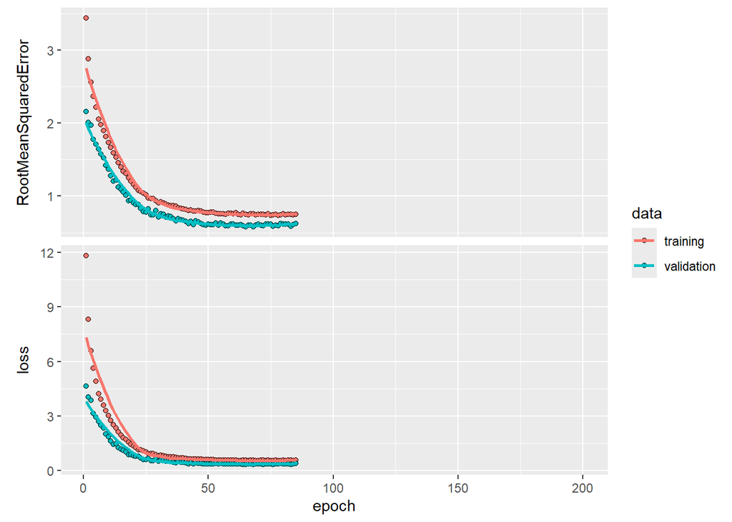

```r
# Compile model
model_7.1 %>% compile(loss = 'mse', optimizer = 'adam', metrics = 'RootMeanSquaredError')

#early stopping
early_stopping <- callback_early_stopping(monitor="val_loss", patience = 20, restore_best_weights = TRUE)

# Fit model to train data
fit_7.1 <- model_7.1 %>% fit(X_train, y_train, epochs = 200, batch_size = 50, validation_split = 0.2, callbacks = list(early_stopping), verbose = 0)

plot(fit_7.1)
```

```r
print(length(fit_7.1$metrics$val_loss)) # how many epochs before early stopping
```

```
[1] 85
```

#### 💪 Problem 7.2

Compute the RMSEs for the training and test data.

```r
# Evaluate on train set
result_train_model_7.1 <- model_7.1 %>% evaluate(X_train, y_train)
```

```
384/384 - 1s - 2ms/step - RootMeanSquaredError: 0.5037 - loss: 0.2537
```

```r
cat("Model 7.1 evaluattion on train data: \n")
```

```
Model 7.1 evaluattion on train data:
```

```r
print(result_train_model_7.1)
```

```
$RootMeanSquaredError
[1] 0.5037234

$loss
[1] 0.2537372
```

```r
# Evaluate on test set
result_test_model_7.1 <- model_7.1 %>% evaluate(X_test, y_test)
```

```
160/160 - 0s - 2ms/step - RootMeanSquaredError: 0.5708 - loss: 0.3258
```

```r
cat("Model 7.1 evaluation on test data: \n")
```

```
Model 7.1 evaluation on test data:
```

```r
print(result_test_model_7.1)
```

```
$RootMeanSquaredError
[1] 0.5708178

$loss
[1] 0.3258329
```

#### 💪 Problem 7.3

Plot a time series plot of the response in the original scale (i.e. counts and not log-counts) for the last week of the test data (last $24\times 7$ observations). In the same figure, plot a time series plot of the fitted values (in the original scale) from Problem 7.1. Comment on the fit.

```r
#Create the data set for last week of data
bike_data_last_week <- tail(bike_all_data_test, 168)

# Format x axis in dataset
bike_data_last_week$dteday <- as.Date(bike_data_last_week$dteday)

# Plot a time series plot of the response in the original scale for the last week of the test data
plot(bike_data_last_week$cnt, xlab = "Hours in the week", ylab = "Bike rental", type = "l", col="blue", main = "Last week bike rental", lwd = 1 )

# Predict cnt in the last week with model in 7.1
x_test_last_week <- tail(X_test, 168) # extract x last week fron the test data
y_predict_last_week_log <- model_7.1 %>% predict(x_test_last_week) # predict y last week in logcnt
```

```
6/6 - 0s - 19ms/step
```

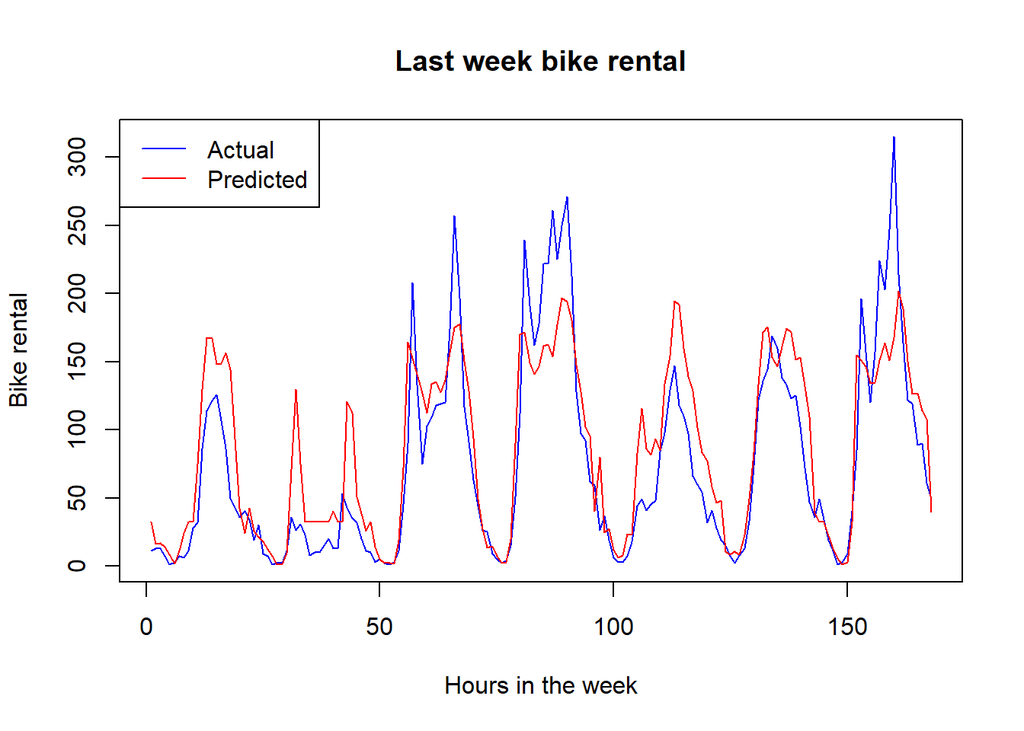

```r
y_predict_last_week_cnt <- exp(y_predict_last_week_log) # convert logcnt to cnt

# Plot the predicted values
lines(y_predict_last_week_cnt, col = "red", lwd = 1)

# Add legends
legend("topleft", legend = c("Actual", "Predicted"), col = c("blue", "red"), lwd = c(1,1))
```

**Note**

The neural network model captures the seasonal trends, which is the ups and down regularly in a day, but misses the magnitude of most peaks and dipsThe sharp changes from neural network model are also smoother with rounder peaks and plateau plunges compared to actual data.

This is the case as we used RMSE as metrics, and MSE as loss function. MSE penalizes the model on sharp deviation, therefore we had to compromise by predicting around the mean. In other words, the model has high bias for the average patterns, with low variance.

#### 💪 Problem 7.4

Propose a better deep learning model than that in Problem 7.1. Add the predictions of your new model to the figure you created in Problem 7.3.

```r
tensorflow::tf$random$set_seed(0)

# I intend to add regularization, tune down drop out rate, add learning rate in optimizer, and divide sample into smaller batches
model_7.4 <- keras_model_sequential() %>%
  # Hidden Layer 1
  layer_dense(units = 16, activation = "relu", input_shape = c(34), kernel_regularizer = regularizer_l2(0.0001)) %>%
  layer_dropout(rate = 0.1) %>%

  # Output Layer
  layer_dense(units = 1, activation = "relu")

# Compile
model_7.4 %>% compile(loss = "mse", optimizer = optimizer_adam(learning_rate = 0.005), metrics = 'RootMeanSquaredError')

# Early stopping callback
early_stop <- callback_early_stopping(monitor = "val_loss", patience = 20, restore_best_weights = TRUE)

# tune down batch size
fit_7.4 <- model_7.4 %>% fit(X_train, y_train, epochs = 200, batch_size = 20, validation_split = 0.2, callbacks = list(early_stop), verbose = 0)
# evaluate on train data
result_train_model_7.4 <- model_7.4 %>% evaluate(X_train, y_train)
```

```
384/384 - 0s - 1ms/step - RootMeanSquaredError: 0.3462 - loss: 0.1277
```

```r
cat("Model 7.4 evaluation on train data: \n")
```

```
Model 7.4 evaluation on train data:
```

```r
print(result_train_model_7.4)
```

```
$RootMeanSquaredError
[1] 0.3462289

$loss
[1] 0.1276839
```

```r
# evaluate on test data
result_test_model_7.4 <- model_7.4 %>% evaluate(X_test, y_test)
```

```
160/160 - 0s - 1ms/step - RootMeanSquaredError: 0.3058 - loss: 0.1013
```

```r
cat("Model 7.4 evaluation on test data: \n")
```

```
Model 7.4 evaluation on test data:
```

```r
print(result_test_model_7.4)
```

```
$RootMeanSquaredError
[1] 0.3058431

$loss
[1] 0.1013494
```

```r
# predict
y_hat_test_7.4 <- model_7.4 %>% predict(X_test)
```

```
160/160 - 0s - 1ms/step
```

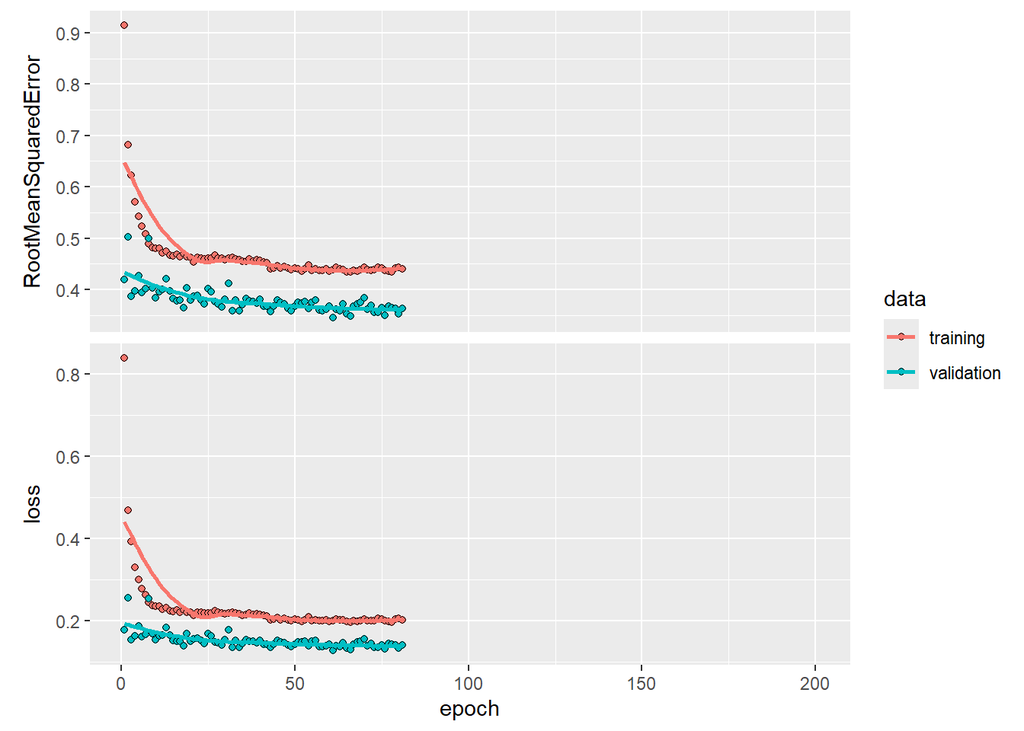

```r
plot(fit_7.4)
```

```r
print(length(fit_7.4$metrics$val_loss))
```

```
[1] 81
```

```r
# Last week of test set
y_pred_7.4_log <- model_7.4 %>% predict(x_test_last_week)
```

```
6/6 - 0s - 8ms/step
```

```r
y_pred_7.4 <- exp(y_pred_7.4_log)

# Last week actual counts
bike_data_last_week <- tail(bike_all_data_test, 168)
y_actual <- bike_data_last_week$cnt

# Base plot: actual vs 7.1 predictions
y_pred_7.1 <- exp(model_7.1 %>% predict(x_test_last_week))
```

```
6/6 - 0s - 12ms/step
```

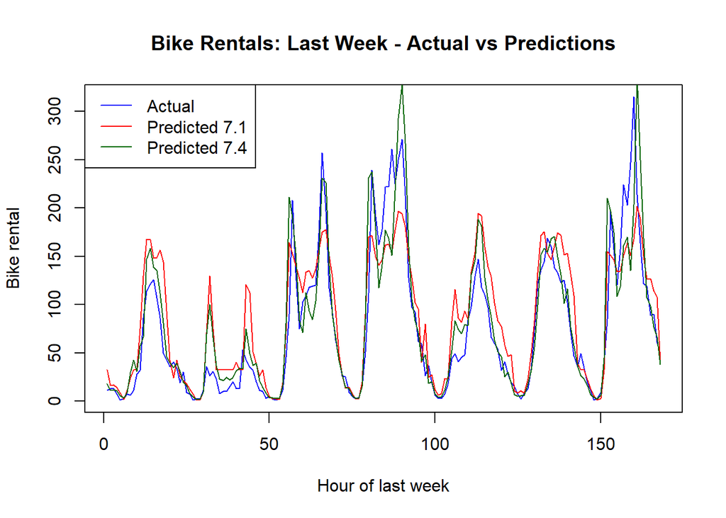

```r
plot(y_actual, type = "l", col = "blue", lwd = 1,
     xlab = "Hour of last week", ylab = "Bike rental",
     main = "Bike Rentals: Last Week - Actual vs Predictions")
lines(y_pred_7.1, col = "red", lwd = 1, lty = 1)
lines(y_pred_7.4, col = "darkgreen", lwd = 1, lty = 1)

legend("topleft", legend = c("Actual", "Predicted 7.1", "Predicted 7.4"),
       col = c("blue", "red", "darkgreen"), lwd = 1, lty = c(1,1,1))
```

```r
tensorflow::tf$random$set_seed(0)

# I intend to add regularization, tune down drop out rate, add learning rate in optimizer, and divide sample into smaller batches
model_7.4 <- keras_model_sequential() %>%
  # Hidden Layer 1
  layer_dense(units = 16, activation = "relu", input_shape = c(34), kernel_regularizer = regularizer_l2(0.0001)) %>%
  layer_dropout(rate = 0.1) %>%
  # Hidden Layer 2
  layer_dense(units = 8, activation = "relu", kernel_regularizer = regularizer_l2(0.0001)) %>%
  layer_dropout(rate = 0.1) %>%
  # Hidden Layer 3
  layer_dense(units = 4, activation = "relu", kernel_regularizer = regularizer_l2(0.0001)) %>%
  layer_dropout(rate = 0.1) %>%
  # Output Layer
  layer_dense(units = 1, activation = "relu")

# Compile
model_7.4 %>% compile(loss = "mse", optimizer = optimizer_adam(learning_rate = 0.005), metrics = 'RootMeanSquaredError')

# Early stopping callback
early_stop <- callback_early_stopping(monitor = "val_loss", patience = 20, restore_best_weights = TRUE)

# tune down batch size
fit_7.4 <- model_7.4 %>% fit(X_train, y_train, epochs = 200, batch_size = 20, validation_split = 0.2, callbacks = list(early_stop), verbose = 0)
# evaluate on train data
result_train_model_7.4 <- model_7.4 %>% evaluate(X_train, y_train)
```

```
384/384 - 1s - 1ms/step - RootMeanSquaredError: 0.3970 - loss: 0.1661
```

```r
cat("Model 7.4 evaluation on train data: \n")
```

```
Model 7.4 evaluation on train data:
```

```r
print(result_train_model_7.4)
```

```
$RootMeanSquaredError
[1] 0.397045

$loss
[1] 0.1661164
```

```r
# evaluate on test data
result_test_model_7.4 <- model_7.4 %>% evaluate(X_test, y_test)
```

```
160/160 - 0s - 1ms/step - RootMeanSquaredError: 0.3855 - loss: 0.1571
```

```r
cat("Model 7.4 evaluation on test data: \n")
```

```
Model 7.4 evaluation on test data:
```

```r
print(result_test_model_7.4)
```

```
$RootMeanSquaredError
[1] 0.3855051

$loss
[1] 0.1570858
```

```r
# predict
y_hat_test_7.4 <- model_7.4 %>% predict(X_test)
```

```
160/160 - 0s - 2ms/step
```

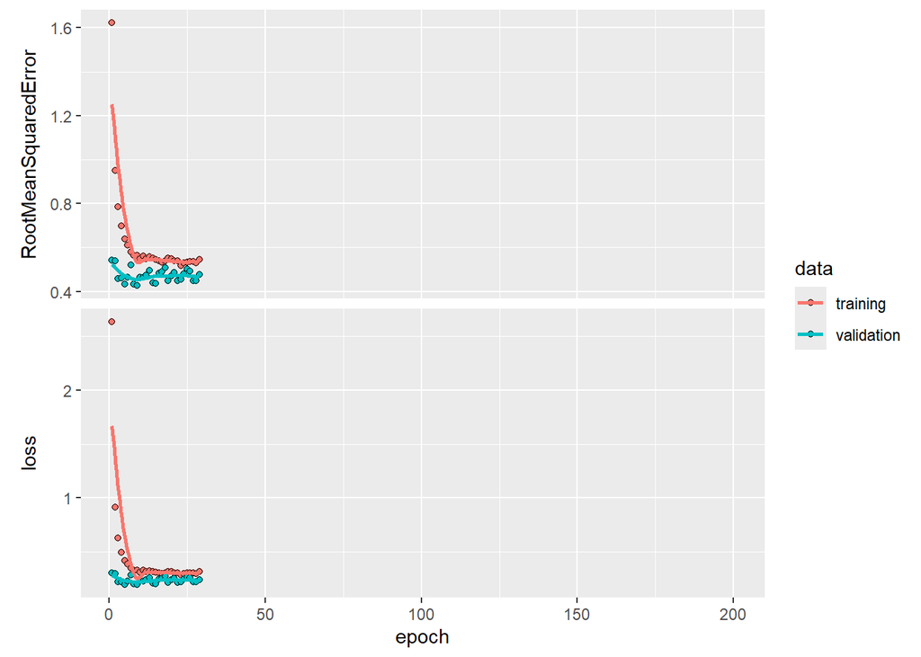

```r
plot(fit_7.4)
```

```r
print(length(fit_7.4$metrics$val_loss))
```

```
[1] 29
```

**Note**

Model 7.4 has much lower RMSEs than model 7.1 -> improved

**Note**

From the plot, model 7.4 reaches further into peaks and dips than model 7.1, with sharper patterns, which is closer to the actual data.

We tried to make the model go into more details by:

- reducing the dropout rate to 0.1 to retain more data (trade off: risky of overfitting)
- add l2 regulation to reduce overfitting from the dropout rate, with just 0.0001 (mild effect) to avoid cancelling dropout rate effect
- reduce batch size to 20 to give it more updates (trade off: the model runs slower)
- increase learning rate to 0.005 instead of the default 0.001 to make the generalization quicker, to cancel the trade off from small batch size (may overshoot if not paired with early stopping)

## 8. Deep learning for classifying images

Arguably, deep learning models first found their big success in image classification problems. The landmark application uses the MNIST dataset, which contains $60000$ and $10000$, respectively, training and test observations, where each observation consists of $784$ gray-scale pixel intensities structured in a $28\times28$ matrix. The pixel intensities range from 0-255, where 0 is (total) black and 255 is (total) white. The data are stored in a so-called `array`, which is a multi-dimensional data structure. The dataset is available in the `keras` and is loaded via the call `dataset_mnist()`. The following code loads and plot the data (requires rotation due to how the data are stored). For computational convenience, we will only use the first $10000$ training observations (out of $60000$) for training the model.

```r
#rm(list=ls()) # Remove variables
#cat("\014") # Clean workspace
suppressMessages(library(pracma)) # For image (matrix) rotation
suppressMessages(library(caret))
suppressMessages(library(keras3))
mnist <- dataset_mnist()
X_train_array <- mnist$train$x[1:10000, , ]
dim(X_train_array) # 10000x28x28 3D array with 10000 images (each 28-by-28 pixels)
```

```
[1] 10000    28    28
```

```r
y_train_array <- mnist$train$y[1:10000]
length(y_train_array) # 10000 element vector with training labels (0-9)
```

```
[1] 10000
```

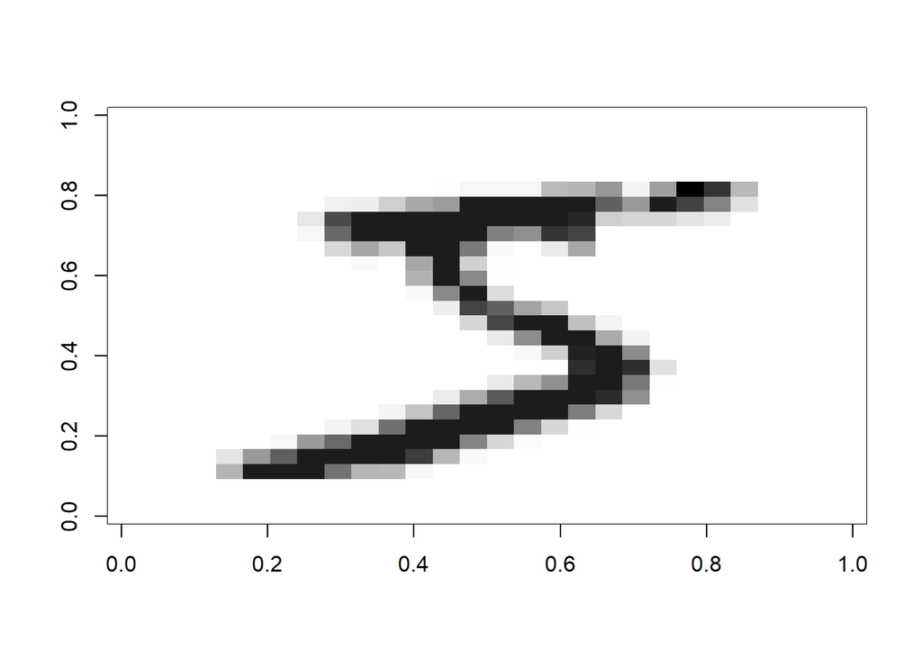

```r
X_test_array <- mnist$test$x
y_test_array <- mnist$test$y
# Plot the first training observation (rot90 rotates)
image(rot90(X_train_array[1, ,], -1), col = gray.colors(256, start = 1, end = 0))
```

```r
# The label of the image above is a five
cat("The label is ", y_train_array[1], sep = "")
```

```
The label is 5
```

```r
X_train <- array_reshape(X_train_array, c(nrow(X_train_array), 784)) # 10000x784 matrix
X_test <- array_reshape(X_test_array, c(nrow(X_test_array), 784))
# rescale to (0, 1)
X_train <- X_train / 255
X_test <- X_test / 255
# One-hot labels
y_train <- to_categorical(y_train_array, 10) # 10000x10 matrix, each row is one-hot (1 for the labelled class and the rest 0)
y_test <- to_categorical(y_test_array, 10)
print(y_train[1, ]) # Represent the label 5 (first element is the label 0)
```

```
 [1] 0 0 0 0 0 1 0 0 0 0
```

The following code builds and fits a two hidden layer dense network with, respectively, 256 and 128 units. See the code for specific settings. Note that we are not monitoring the AUC anymore because the classification problem has multiple classes. The code also predicts the class probabilities for the test images and inspects a special case where the classifier is very uncertain.

```r
tensorflow::tf$random$set_seed(0)

model_MNIST_2layer <- keras_model_sequential()
model_MNIST_2layer %>%
  # Add first hidden layer
  layer_dense(units = 256, activation = 'relu', input_shape = c(784)) %>%
  # Add regularisation via dropout to the first hidden layer
  layer_dropout(rate = 0.3) %>%
  layer_dense(units = 128, activation = 'relu') %>%
  # Add regularisation via dropout to the first hidden layer
  layer_dropout(rate = 0.3) %>%
  # Add layer that connects to the observations
  layer_dense(units = 10, activation = 'softmax') # usually used for images recognition
summary(model_MNIST_2layer)
```

```
Model: "sequential_7"
┌───────────────────────────────────┬──────────────────────────┬───────────────
│ Layer (type)                      │ Output Shape             │       Param #
├───────────────────────────────────┼──────────────────────────┼───────────────
│ dense_21 (Dense)                  │ (None, 256)              │       200,960
├───────────────────────────────────┼──────────────────────────┼───────────────
│ dropout_14 (Dropout)              │ (None, 256)              │             0
├───────────────────────────────────┼──────────────────────────┼───────────────
│ dense_22 (Dense)                  │ (None, 128)              │        32,896
├───────────────────────────────────┼──────────────────────────┼───────────────
│ dropout_15 (Dropout)              │ (None, 128)              │             0
├───────────────────────────────────┼──────────────────────────┼───────────────
│ dense_23 (Dense)                  │ (None, 10)               │         1,290
└───────────────────────────────────┴──────────────────────────┴───────────────
 Total params: 235,146 (918.54 KB)
 Trainable params: 235,146 (918.54 KB)
 Non-trainable params: 0 (0.00 B)
```

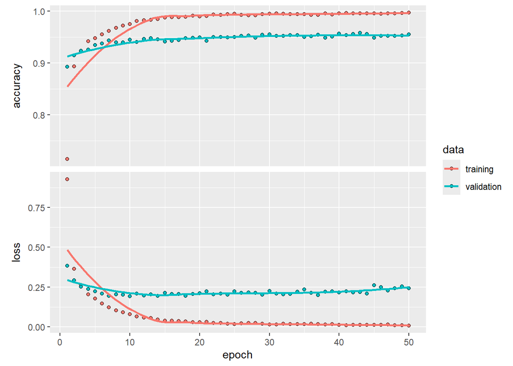

```r
# Compile model
model_MNIST_2layer %>% compile(loss = 'categorical_crossentropy', optimizer = 'adam', metrics = c('accuracy'))

# Fit model
model_MNIST_2layer_fit <- model_MNIST_2layer %>% fit(X_train, y_train, epochs = 50, batch_size = 100, validation_split = 0.2, verbose = 0)
plot(model_MNIST_2layer_fit)
```

```r
# Prediction test data. The ith row is the probability distribution over the classes (0-9) for the ith test image
y_pred_test_dl_2layer <- model_MNIST_2layer %>% predict(X_test)
```

```
313/313 - 1s - 2ms/step
```

```r
# For fun, get an observation where the prediction is not certain
indices <-  which(rowSums(y_pred_test_dl_2layer <= 0.55 & y_pred_test_dl_2layer >= 0.45) == 2) #  Gets observations for which the classifier is unsure (have two cells in the interval (0.45, 0.55).
ind <- indices[1] # Taking the first
print(ind)
```

```
[1] 342
```

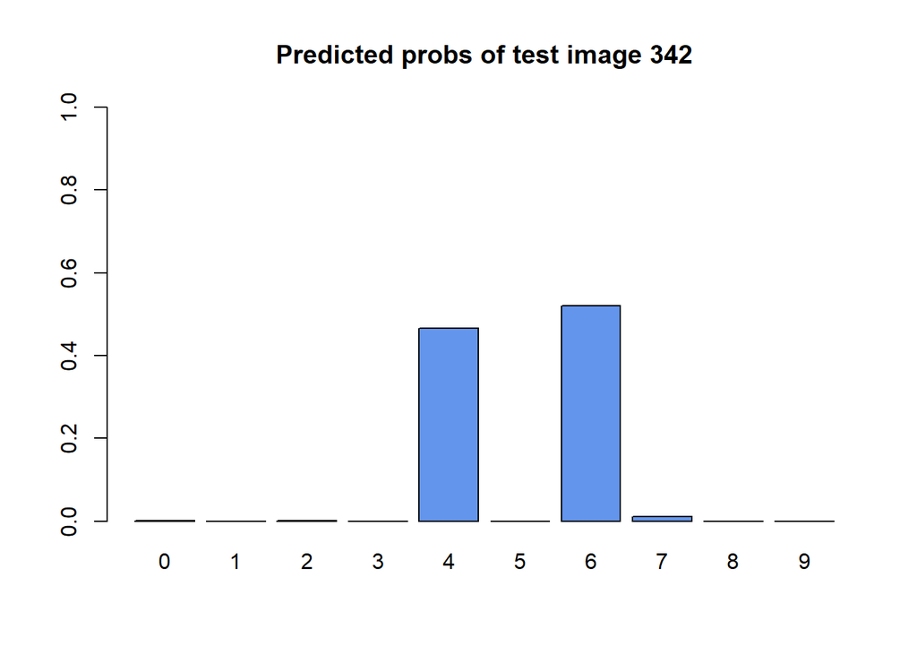

```r
barplot(names.arg = 0:9, y_pred_test_dl_2layer[ind, ], col = "cornflowerblue", ylim = c(0, 1), main = paste("Predicted probs of test image ", ind, sep = ""))
```

```r
cat("Actual label: ", which.max(y_test[ind, ]) - 1, ", Predicted label:", which.max(y_pred_test_dl_2layer[ind, ]) - 1, sep = "")
```

```
Actual label: 6, Predicted label:6
```

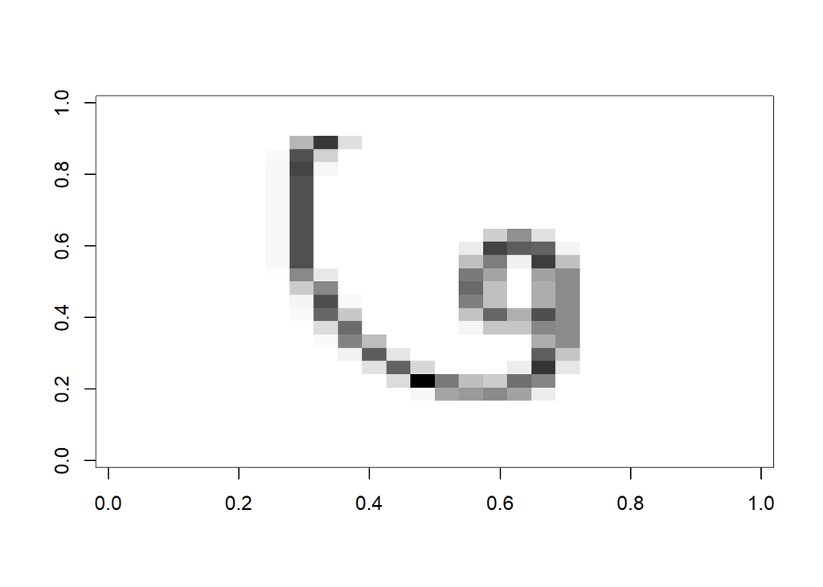

```r
image(rot90(X_test_array[ind, ,], -1), col = gray.colors(256, start = 1, end = 0))
```

#### 💪 Problem 8.1

Is the model over- or underfitting the data? Explain. Given the same model structure, propose a fix to the issue and implement it.

```r
# evaluate model_MNIST_2layer
result_train_MNIST_2layer <- model_MNIST_2layer %>% evaluate(X_train, y_train)
```

```
313/313 - 1s - 3ms/step - accuracy: 0.9911 - loss: 0.0488
```

```r
cat("Matias' MNIST 2 layer model train data evaluation:\n")
```

```
Matias' MNIST 2 layer model train data evaluation:
```

```r
print(result_train_MNIST_2layer)
```

```
$accuracy
[1] 0.9911

$loss
[1] 0.04879418
```

```r
result_test_MNIST_2layer <- model_MNIST_2layer %>% evaluate(X_test, y_test)
```

```
313/313 - 1s - 2ms/step - accuracy: 0.9593 - loss: 0.2199
```

```r
cat("Matias' MNIST 2 layer model test data evaluation:\n")
```

```
Matias' MNIST 2 layer model test data evaluation:
```

```r
print(result_test_MNIST_2layer)
```

```
$accuracy
[1] 0.9593

$loss
[1] 0.2198943
```

**Note**

Looking at the accuracy evaluated, and the accuracy plot, where training accuracy is increasing, and significantly higher than the validation accuracy, this model is slighlty overfitting to the training data. The loss plot also proposes the same thing, as training loss is much lower than validation loss, and validation loss even increasing at the end of the epochs. However, the accuracy of this model is great (>95%).

To improve the model, we can add early stop, L2 regulations, tune the dropout rate (increase), or reduce the number of neurons.

```r
tensorflow::tf$random$set_seed(0)
model_MNIST_2layer <- keras_model_sequential()
model_MNIST_2layer %>%
  # Add first hidden layer + add l2 penalty to improve overfit
  layer_dense(units = 256, activation = 'relu', input_shape = c(784), kernel_regularizer = regularizer_l2(0.001)) %>%
  # Add regularisation via dropout to the first hidden layer
  layer_dropout(rate = 0.3) %>%
  # Add 2nd hidden layer + add l2 penalty to improve overfit
  layer_dense(units = 128, activation = 'relu', kernel_regularizer = regularizer_l2(0.001)) %>%
  # Add regularisation via dropout to the first hidden layer
  layer_dropout(rate = 0.3) %>%
  # Add layer that connects to the observations
  layer_dense(units = 10, activation = 'softmax') # usually used for images recognition
summary(model_MNIST_2layer)
```

```
Model: "sequential_8"
┌───────────────────────────────────┬──────────────────────────┬───────────────
│ Layer (type)                      │ Output Shape             │       Param #
├───────────────────────────────────┼──────────────────────────┼───────────────
│ dense_24 (Dense)                  │ (None, 256)              │       200,960
├───────────────────────────────────┼──────────────────────────┼───────────────
│ dropout_16 (Dropout)              │ (None, 256)              │             0
├───────────────────────────────────┼──────────────────────────┼───────────────
│ dense_25 (Dense)                  │ (None, 128)              │        32,896
├───────────────────────────────────┼──────────────────────────┼───────────────
│ dropout_17 (Dropout)              │ (None, 128)              │             0
├───────────────────────────────────┼──────────────────────────┼───────────────
│ dense_26 (Dense)                  │ (None, 10)               │         1,290
└───────────────────────────────────┴──────────────────────────┴───────────────
 Total params: 235,146 (918.54 KB)
 Trainable params: 235,146 (918.54 KB)
 Non-trainable params: 0 (0.00 B)
```

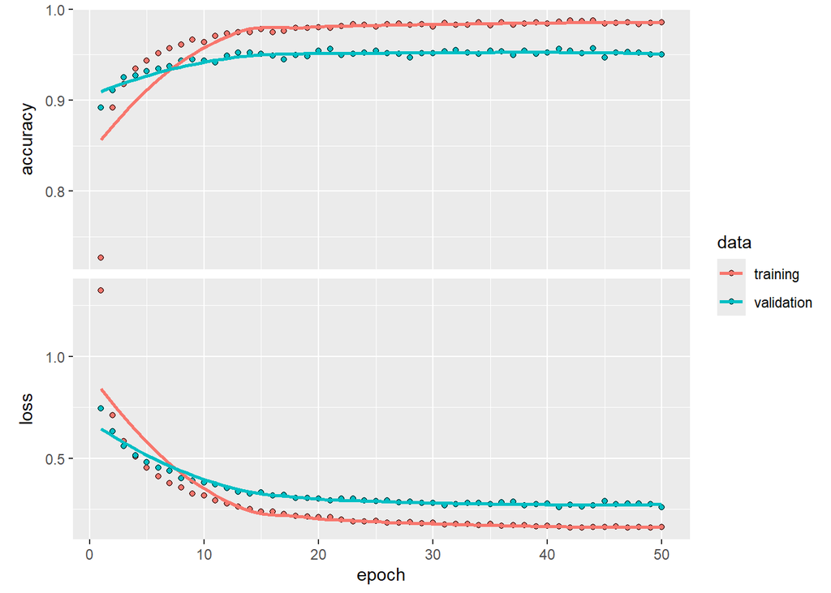

```r
# Compile model
model_MNIST_2layer %>% compile(loss = 'categorical_crossentropy', optimizer = 'adam', metrics = c('accuracy'))

# Fit model
model_MNIST_2layer_fit <- model_MNIST_2layer %>% fit(X_train, y_train, epochs = 50, batch_size = 100, validation_split = 0.2, verbose = 0)
plot(model_MNIST_2layer_fit)
```

```r
# evaluate model_MNIST_2layer
result_train_MNIST_2layer <- model_MNIST_2layer %>% evaluate(X_train, y_train)
```

```
313/313 - 1s - 2ms/step - accuracy: 0.9879 - loss: 0.1522
```

```r
cat("New MNIST 2 layer model train data evaluation:\n")
```

```
New MNIST 2 layer model train data evaluation:
```

```r
print(result_train_MNIST_2layer)
```

```
$accuracy
[1] 0.9879

$loss
[1] 0.1521987
```

```r
result_test_MNIST_2layer <- model_MNIST_2layer %>% evaluate(X_test, y_test)
```

```
313/313 - 1s - 2ms/step - accuracy: 0.9601 - loss: 0.2488
```

```r
cat("New MNIST 2 layer model test data evaluation:\n")
```

```
New MNIST 2 layer model test data evaluation:
```

```r
print(result_test_MNIST_2layer)
```

```
$accuracy
[1] 0.9601

$loss
[1] 0.2488402
```

We now consider including 2D convolutional layers, which are tailored for when the features have a grid-like structure, such as $28\times 28$ images above (before they were flattened). The data structure in convolutional filters has an additional dimension known as the *number of channels.* This is essentially the dimension of the output in a pixel. In gray-scale color as in the MNIST data, there is only one channel - the white pixel intensity (with outcomes 0-255, 0 is (total) black and 255 is (total) white). Another example is the RGB color scheme, which has three channels since the pixel intensity is three dimensional (Red, Green, Blue), where each of the colors have a corresponding pixel intensity with outcomes 0-255. For example, the triple (0, 255, 0) represents the color green, and (255, 255, 0) represents the color yellow. The following code shows how to create a dataset suitable for input in a convolutional filter for the MNIST data. Some explanation of the code follows.

```r
X_train <- array(X_train_array, c(10000, 28, 28, 1)) # The last dimension is the channel
X_test <- array(X_test_array, c(10000, 28, 28, 1))
# Transform values into [0,1] range
X_train <- X_train / 255
X_test <- X_test / 255
# One-hot labels
y_train <- to_categorical(y_train_array, 10) # 10000x10 matrix, each row is one-hot (1 for the labelled class and the rest 0)
y_test <- to_categorical(y_test_array, 10)

# Define model
model_MNIST_2conv1layer <- keras_model_sequential() %>%
  # First convolutional layer
  layer_conv_2d(filters = 32, kernel_size = c(3,3), activation = 'relu',
                input_shape = c(28, 28, 1)) %>%
  # Second convolutional layer
  layer_conv_2d(filters = 64, kernel_size = c(3,3), activation = 'relu') %>%
  # Add a pooling layer after the second convolutional layer
  layer_max_pooling_2d(pool_size = c(2, 2)) %>%
  # Add regularisation via dropout to the second convolutional layer
  layer_dropout(rate = 0.4) %>%
  # Flatten the output of the preceeding layer
  layer_flatten() %>%
  # A third layer fully connected (input has been flattened)
  layer_dense(units = 128, activation = 'relu') %>%
  # Add regularisation via dropout to preceeding layer
  layer_dropout(rate = 0.4) %>%
  # Add layer that connects to the observations
  layer_dense(units = 10, activation = 'softmax')
# Compile model
model_MNIST_2conv1layer %>% compile(loss = 'categorical_crossentropy', optimizer = 'adam', metrics = c('accuracy'))
model_MNIST_2conv1layer_fit <- model_MNIST_2conv1layer %>% fit(X_train, y_train, batch_size = 100, epochs = 15, validation_split = 0.2)
```

```
80/80 - 6s - 78ms/step - accuracy: 0.8095 - loss: 0.6185 - val_accuracy: 0.9270 - val_loss: 0.2573
80/80 - 5s - 63ms/step - accuracy: 0.9379 - loss: 0.2107 - val_accuracy: 0.9530 - val_loss: 0.1620
80/80 - 5s - 59ms/step - accuracy: 0.9581 - loss: 0.1416 - val_accuracy: 0.9635 - val_loss: 0.1313
80/80 - 5s - 62ms/step - accuracy: 0.9657 - loss: 0.1088 - val_accuracy: 0.9670 - val_loss: 0.1097
80/80 - 5s - 67ms/step - accuracy: 0.9724 - loss: 0.0882 - val_accuracy: 0.9705 - val_loss: 0.1076
80/80 - 5s - 68ms/step - accuracy: 0.9779 - loss: 0.0696 - val_accuracy: 0.9670 - val_loss: 0.1213
80/80 - 6s - 69ms/step - accuracy: 0.9819 - loss: 0.0550 - val_accuracy: 0.9705 - val_loss: 0.0950
80/80 - 6s - 72ms/step - accuracy: 0.9872 - loss: 0.0428 - val_accuracy: 0.9700 - val_loss: 0.0977
80/80 - 6s - 75ms/step - accuracy: 0.9862 - loss: 0.0406 - val_accuracy: 0.9775 - val_loss: 0.0916
80/80 - 6s - 78ms/step - accuracy: 0.9876 - loss: 0.0384 - val_accuracy: 0.9720 - val_loss: 0.1008
80/80 - 5s - 68ms/step - accuracy: 0.9898 - loss: 0.0294 - val_accuracy: 0.9795 - val_loss: 0.0957
80/80 - 6s - 71ms/step - accuracy: 0.9911 - loss: 0.0292 - val_accuracy: 0.9750 - val_loss: 0.0972
80/80 - 6s - 76ms/step - accuracy: 0.9906 - loss: 0.0269 - val_accuracy: 0.9760 - val_loss: 0.1064
80/80 - 6s - 69ms/step - accuracy: 0.9912 - loss: 0.0265 - val_accuracy: 0.9730 - val_loss: 0.1128
80/80 - 6s - 69ms/step - accuracy: 0.9920 - loss: 0.0227 - val_accuracy: 0.9800 - val_loss: 0.1005
```

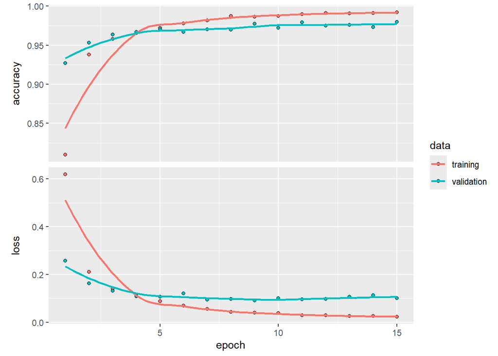

```r
plot(model_MNIST_2conv1layer_fit)
```

```r
y_pred_test_dl_2conv1layer <- model_MNIST_2conv1layer %>% predict(X_test)
```

```
313/313 - 2s - 8ms/step
```

We only explain the calls that have not been explained previously. The `layer_conv_2d()` call adds a layer with the number of filters specified by the argument `filter`, where each filter has the size specified by the argument `kernel_size`. The `layer_max_pooling()` call adds a layer that down-samples the output of the preceding one, using a special filter without trainable parameters. This special filter takes the maximum value over a region (with size specified by the `pool_size` argument) of the previous output, see Figure 6.14 in Lindholm et al. (2022). Finally, the `layer_flatten()` call flattens the output of the preceding layer. The reason for doing this is to allow the next layer to be fully connected.

#### 💪 Problem 8.2

Compare the deep learning model with convolutional layers to that in Problem 8.1. Discuss the results.

```r
# evaluate the convolutional layer model
result_train_MNIST_2conv1layer <- model_MNIST_2conv1layer %>% evaluate(X_train, y_train)
```

```
313/313 - 2s - 7ms/step - accuracy: 0.9955 - loss: 0.0224
```

```r
cat("Matias' MNIST 2 layer model train data evaluation:\n")
```

```
Matias' MNIST 2 layer model train data evaluation:
```

```r
print(result_train_MNIST_2conv1layer)
```

```
$accuracy
[1] 0.9955

$loss
[1] 0.0223531
```

```r
result_test_MNIST_2conv1layer <- model_MNIST_2conv1layer %>% evaluate(X_test, y_test)
```

```
313/313 - 2s - 7ms/step - accuracy: 0.9808 - loss: 0.0689
```

```r
cat("Matias' MNIST 2 layer model test data evaluation:\n")
```

```
Matias' MNIST 2 layer model test data evaluation:
```

```r
print(result_test_MNIST_2conv1layer)
```

```
$accuracy
[1] 0.9808

$loss
[1] 0.06885323
```

**Note**

Based on the plots of convolutional layers model and deep learning model, we can see that convolutional layers have reduced the gaps in accuracy and loss between train and validation data, therefore the model is less overfitting than the deep learning one. Particularly, in the convolutional layers model, the loss and accuracy of validation data are improved significantly, while requiring only one third of the epochs to converge, which can save some time and computational power.

The accuracy in test data has been improved considerably, by 2%, which is quite impressive considering that accuracy in the deep learning model was already high at 95%. It could be thanks to convolutional layers model’s the ability to exploit the 2D structure of images and local spatial correlations.

Convolutional layers can creates such improvement as they are designed to first learn simple features (edges, corners), then combine them into complex patterns (shapes, objects). This hierarchical feature learning is more effective for image tasks than fully connected layers, which treat all pixels as independent and lose spatial context.